# Initial study - Additional Analyses

Kathryn Denning

6/18/2020

# Stereotype moderator analysis

## Results

```r
#model
projmodel_stereo <- lmer(MFQTarg ~ MFQSelf_c * MFQStereo_c *
                                    inoutgroup_effects * ident_c +
                                    (MFQSelf_c|subid),
                                 data = stereo_analysis)

#results
tab_model(projmodel_stereo,
          title = "Projection moderated by stereotyping")
```

Projection moderated by stereotyping

|  | MFQ Targ |  |  |
| --- | --- | --- | --- |
| Predictors | Estimates | CI | p |
| (Intercept) | 4.19 | 4.15 – 4.22 | **<0.001** |
| MFQSelf_c | 0.16 | 0.14 – 0.18 | **<0.001** |
| MFQStereo_c | 0.45 | 0.44 – 0.47 | **<0.001** |
| inoutgroup_effects | 0.12 | 0.05 – 0.19 | **0.001** |
| ident_c | 0.02 | 0.00 – 0.04 | **0.023** |
| MFQSelf_c * MFQStereo_c | -0.01 | -0.01 – 0.00 | 0.070 |
| MFQSelf_c * inoutgroup_effects | 0.37 | 0.33 – 0.40 | **<0.001** |
| MFQStereo_c * inoutgroup_effects | -0.15 | -0.17 – -0.12 | **<0.001** |
| MFQSelf_c * ident_c | -0.00 | -0.01 – 0.01 | 0.966 |
| MFQStereo_c * ident_c | 0.00 | -0.01 – 0.01 | 0.790 |
| inoutgroup_effects * ident_c | 0.04 | 0.00 – 0.08 | **0.038** |
| (MFQSelf_c * MFQStereo_c) * inoutgroup_effects | -0.02 | -0.03 – -0.01 | **<0.001** |
| (MFQSelf_c * MFQStereo_c) * ident_c | -0.00 | -0.01 – 0.00 | 0.152 |
| (MFQSelf_c *inoutgroup_effects)* ident_c | 0.03 | 0.01 – 0.05 | **0.003** |
| (MFQStereo_c *inoutgroup_effects)* ident_c | -0.04 | -0.06 – -0.03 | **<0.001** |
| (MFQSelf_c * MFQStereo_c * inoutgroup_effects) * ident_c | -0.02 | -0.02 – -0.01 | **<0.001** |
| Random Effects |  |  |  |
| σ<sup>2</sup> | 1.06 |  |  |
| τ<sub>00</sub> <sub>subid</sub> | 0.19 |  |  |
| τ<sub>11</sub> <sub>subid.MFQSelf_c</sub> | 0.05 |  |  |
| ρ<sub>01</sub> <sub>subid</sub> | 0.04 |  |  |
| ICC | 0.23 |  |  |
| N <sub>subid</sub> | 725 |  |  |
| Observations | 21514 |  |  |
| Marginal R<sup>2</sup> / Conditional R<sup>2</sup> | 0.424 / 0.557 |  |  |

```r
#confidence intervals for ones that rounding to two in tab_model isn't enough info
confint(projmodel_stereo)
```

```
##                                                         2.5 %        97.5 %
## .sig01                                            0.411604364  0.4671602033
## .sig02                                           -0.058164880  0.1362579540
## .sig03                                            0.201738067  0.2325189514
## .sigma                                            1.019911152  1.0400539731
## (Intercept)                                       4.149956228  4.2222746396
## MFQSelf_c                                         0.140862449  0.1800599333
## MFQStereo_c                                       0.442167603  0.4652837829
## inoutgroup_effects                                0.048443738  0.1930410966
## ident_c                                           0.003286262  0.0437615454
## MFQSelf_c:MFQStereo_c                            -0.011910040  0.0005025631
## MFQSelf_c:inoutgroup_effects                      0.325814147  0.4041718195
## MFQStereo_c:inoutgroup_effects                   -0.168341196 -0.1223858989
## MFQSelf_c:ident_c                                -0.010959906  0.0104966212
## MFQStereo_c:ident_c                              -0.005392132  0.0071108019
## inoutgroup_effects:ident_c                        0.002332551  0.0832795877
## MFQSelf_c:MFQStereo_c:inoutgroup_effects         -0.034683069 -0.0100026132
## MFQSelf_c:MFQStereo_c:ident_c                    -0.005582614  0.0008676917
## MFQSelf_c:inoutgroup_effects:ident_c              0.011173347  0.0540784405
## MFQStereo_c:inoutgroup_effects:ident_c           -0.055003223 -0.0299997590
## MFQSelf_c:MFQStereo_c:inoutgroup_effects:ident_c -0.023693963 -0.0107937378
```

## Plot: Projection by stereo x ident

```r
describe(stereo_analysis$MFQStereo_c)
```

```
##    vars     n mean   sd median trimmed  mad   min  max range  skew kurtosis
## X1    1 21514    0 1.67   0.15    0.09 1.48 -2.85 2.15     5 -0.32    -1.11
##      se
## X1 0.01
```

```r
describe(stereo_analysis$ident_c)
```

```
##    vars     n  mean  sd median trimmed mad   min  max range  skew kurtosis   se
## X1    1 21514 -0.01 1.8   0.06       0 1.8 -4.23 3.77     8 -0.04    -0.37 0.01
```

```r
proj_stereo_effects <- effect(term = "MFQSelf_c:MFQStereo_c:ident_c",
                           xlevels = list(ident_c = c(-1.8, 0, 1.8),
                                         MFQStereo_c = c(-1.67, 0, 1.67)),
                           mod = projmodel_stereo)

proj_stereo_int <- as.data.frame(proj_stereo_effects)

proj_stereo_int$Stereotyping <- as.factor(proj_stereo_int$MFQStereo_c)
proj_stereo_int$Identification <- as.factor(proj_stereo_int$ident_c)

ident_label <- c("-1.8" = "Low identification \n (1 SD below)",
                 "0" = "Average identification",
                 "1.8" = "High identificatiion \n (1 SD above)")

stereo_label <- c("-1.67" = "Low stereotyping \n (1 SD below)",
                  "0" = "Average stereotyping",
                  "1.67" = "High stereotyping \n (1 SD above)")
```

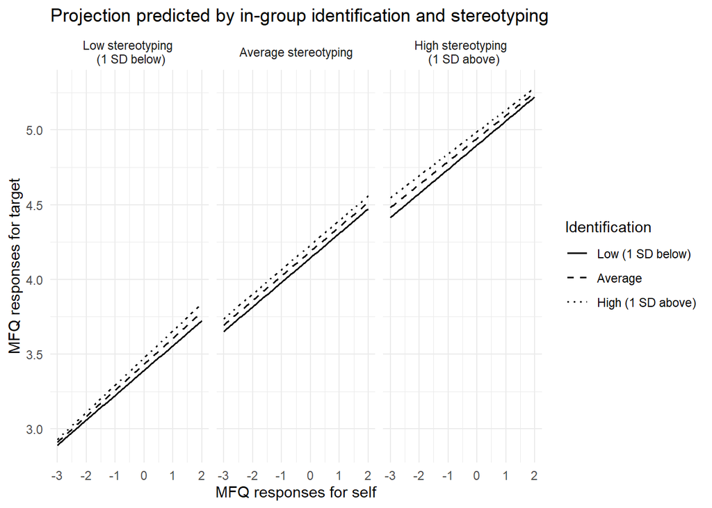

```r
ggplot(proj_stereo_int, aes(MFQSelf_c,
                             fit,
                             group = Identification,
                             color = Identification)) +
  geom_smooth(method = "lm", se = FALSE, size = .7, colour = "black",
              aes(linetype = Identification)) +
  facet_wrap(~Stereotyping, labeller =
               labeller(Stereotyping = stereo_label)) +
  scale_linetype_manual("Identification", breaks = c(-1.8, 0, 1.8),
                       labels = c("Low (1 SD below)",
                                  "Average",
                                  "High (1 SD above)"),
                       values = c("solid",
                                   "dashed",
                                  "dotted")) +
  theme_minimal() +
  labs(title = "Projection predicted by in-group identification and stereotyping",
       x = "MFQ responses for self",
       y = "MFQ responses for target")
```

## Plot: Projection by stereo x group

```r
proj_stereo_targME_effects <- effect(term = "MFQSelf_c:MFQStereo_c:inoutgroup_effects",
                           xlevels = list(inoutgroup_effects = c(-.5, .5),
                                         MFQStereo_c = c(-1.67, 0, 1.67)),
                           mod = projmodel_stereo)

proj_stereo_targME_effects<- as.data.frame(proj_stereo_targME_effects)

proj_stereo_targME_effects$Stereotyping <- as.factor(proj_stereo_targME_effects$MFQStereo_c)
proj_stereo_targME_effects$Group <- as.factor(proj_stereo_targME_effects$inoutgroup_effects)

stereo_label <- c("-1.67" = "Low stereotyping \n (1 SD below)",
                  "0" = "Average stereotyping",
                  "1.67" = "High stereotyping \n (1 SD above)")
```

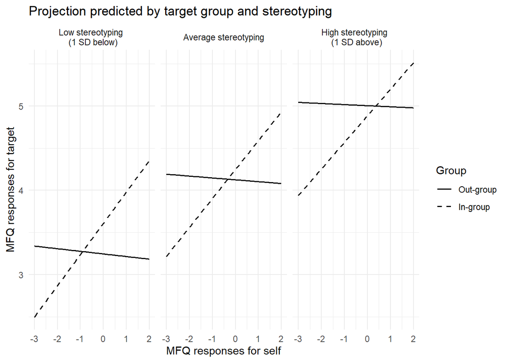

```r
# ggpreview <- function(...) {
#   fname <- tempfile(fileext = ".png")
#   ggsave(filename = fname, ...)
#   system2("open", fname)
#   invisible(NULL)
# }

knitr::opts_chunk$set(fig.width = 8, fig.height = 6)

ggplot(proj_stereo_targME_effects, aes(MFQSelf_c,
                             fit,
                             group = Group,
                             color = Group)) +
  geom_smooth(method = "lm", se = FALSE, size = .7, colour = "black",
              aes(linetype = Group)) +
  facet_wrap(~Stereotyping, labeller =
               labeller(Stereotyping = stereo_label)) +
  scale_linetype_manual("Group", breaks = c(-0.5, 0.5),
                       labels = c("Out-group",
                                  "In-group"),
                       values = c("solid",
                                   "dashed")) +
  theme_minimal() +
  labs(title = "Projection predicted by target group and stereotyping",
       x = "MFQ responses for self",
       y = "MFQ responses for target")
```

```r
# ggpreview(width = 8, height = 6, units = "in")
```

## Plot: Projection by group x ident

```r
initial_study_3way <- effect(term = "MFQSelf_c:inoutgroup_effects:ident_c",
                           xlevels = list(ident_c = c(-1.8, 0, 1.8),
                                         inoutgroup_effects = c(-.5,.5)),
                           mod = projmodel_stereo)

initial_study_3way <- as.data.frame(initial_study_3way)

initial_study_3way$Group <- as.factor(initial_study_3way$inoutgroup_effects)
initial_study_3way$Identification <- as.factor(initial_study_3way$ident_c)
```

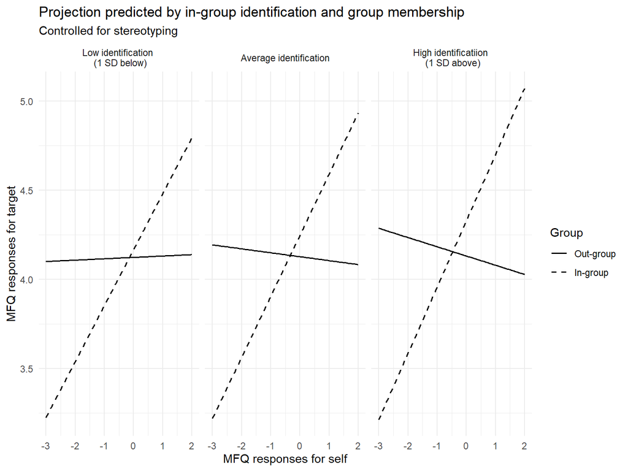

```r
# ggpreview <- function(...) {
#   fname <- tempfile(fileext = ".png")
#   ggsave(filename = fname, ...)
#   system2("open", fname)
#   invisible(NULL)
# }

knitr::opts_chunk$set(fig.width = 8, fig.height = 6)

ggplot(initial_study_3way, aes(MFQSelf_c,
                             fit,
                             group = Group,
                             color = Group)) +
  geom_smooth(method = "lm", se = FALSE, size = .7, colour = "black",
              aes(linetype = Group)) +
  facet_wrap(~Identification, labeller =
               labeller(Identification = ident_label)) +
  scale_linetype_manual("Group", breaks = c(-.5, .5),
                       labels = c("Out-group", "In-group"),
                       values = c("solid",
                                   "dashed")) +
  theme_minimal() +
  labs(title = "Projection predicted by in-group identification and group membership",
       subtitle = "Controlled for stereotyping",
       x = "MFQ responses for self",
       y = "MFQ responses for target")
```

```r
# ggpreview(width = 8, height = 6, units = "in")
```

## Plot: Projection by group

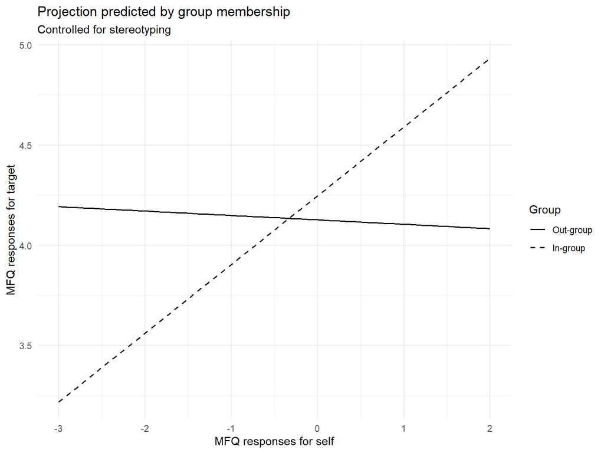

```r
# ggpreview <- function(...) {
#   fname <- tempfile(fileext = ".png")
#   ggsave(filename = fname, ...)
#   system2("open", fname)
#   invisible(NULL)
# }

knitr::opts_chunk$set(fig.width = 8, fig.height = 6)

ggplot(initial_study_main_group, aes(MFQSelf_c,
                               fit,
                               group = Group,
                               color = Group)) +
  geom_smooth(method = "lm", se = FALSE, size = .7, colour = "black",
              aes(linetype = Group)) +
  scale_linetype_manual("Group", breaks = c(-.5, .5),
                       labels = c("Out-group", "In-group"),
                       values = c("solid",
                                  "dashed")) +
  theme_minimal() +
  labs(title = "Projection predicted by group membership",
       subtitle = "Controlled for stereotyping",
       x = "MFQ responses for self",
       y = "MFQ responses for target")
```

```r
# ggpreview(width = 8, height = 6, units = "in")
```

## Plot: Projection by stereo x ident x group

```r
proj_stereo_4way <- effect(term = "MFQSelf_c:MFQStereo_c:inoutgroup_effects:ident_c",
                           xlevels = list(ident_c = c(-1.8, 0, 1.8),
                                         MFQStereo_c = c(-1.67, 0, 1.67),
                                         inoutgroup_effects = c(-.5,.5)),
                           mod = projmodel_stereo)

proj_stereo_4way <- as.data.frame(proj_stereo_4way)

group_label <- c()

proj_stereo_4way %<>%
  mutate(Identification = as.factor(ident_c),
         Stereotyping = as.factor(MFQStereo_c),
         TargetGroup = as.factor(inoutgroup_effects)) %>%
  mutate(TargetGroup = dplyr::recode(TargetGroup,
                                     `-0.5` = "Out-group",
                                     `0.5` = "In-group"))
```

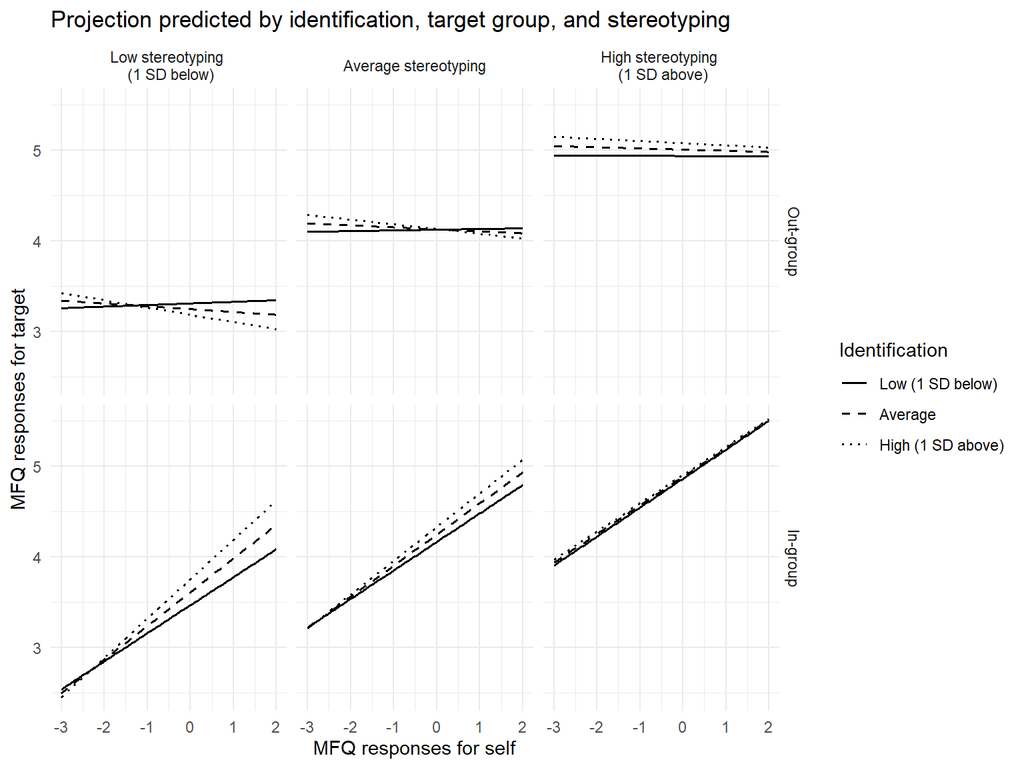

```r
# ggpreview <- function(...) {
#   fname <- tempfile(fileext = ".png")
#   ggsave(filename = fname, ...)
#   system2("open", fname)
#   invisible(NULL)
# }

knitr::opts_chunk$set(fig.width = 8, fig.height = 6)

ggplot(proj_stereo_4way, aes(MFQSelf_c,
                             fit,
                             group = Identification)) +
  geom_smooth(method = "lm", se = FALSE, size = .7, colour = "black",
              aes(linetype = Identification)) +
  facet_grid(vars(TargetGroup), vars(Stereotyping),
             labeller = labeller(Stereotyping = stereo_label)) +
  scale_linetype_manual("Identification", breaks = c(-1.8, 0, 1.8),
                       labels = c("Low (1 SD below)",
                                  "Average",
                                  "High (1 SD above)"),
                       values = c("solid",
                                   "dashed",
                                  "dotted")) +
  theme_minimal() +
  labs(title = "Projection predicted by identification, target group, and stereotyping",
       x = "MFQ responses for self",
       y = "MFQ responses for target")
```

```r
# ggpreview(width = 8, height = 6, units = "in")
```

# Subset analyses

## Subgroups of target group

### Out-group

```r
out_only <- stereo_analysis %>% filter(inoutgroup_effects != .5)

projmodel_stereo_out <- lmer(MFQTarg ~ MFQSelf_c * MFQStereo_c * ident_c +
                                    (MFQSelf_c|subid),
                                 data = out_only)


tab_model(projmodel_stereo_out,
          title = "Projection moderated by stereotyping with out-group data only")
```

Projection moderated by stereotyping with out-group data only

|  | MFQ Targ |  |  |
| --- | --- | --- | --- |
| Predictors | Estimates | CI | p |
| (Intercept) | 4.12 | 4.07 – 4.18 | **<0.001** |
| MFQSelf_c | -0.02 | -0.05 – 0.01 | 0.142 |
| MFQStereo_c | 0.53 | 0.51 – 0.54 | **<0.001** |
| ident_c | 0.00 | -0.03 – 0.03 | 0.872 |
| MFQSelf_c * MFQStereo_c | 0.00 | -0.00 – 0.01 | 0.371 |
| MFQSelf_c * ident_c | -0.02 | -0.03 – 0.00 | 0.061 |
| MFQStereo_c * ident_c | 0.02 | 0.01 – 0.03 | **<0.001** |
| (MFQSelf_c * MFQStereo_c) * ident_c | 0.01 | 0.00 – 0.01 | **0.009** |
| Random Effects |  |  |  |
| σ<sup>2</sup> | 1.28 |  |  |
| τ<sub>00</sub> <sub>subid</sub> | 0.21 |  |  |
| τ<sub>11</sub> <sub>subid.MFQSelf_c</sub> | 0.06 |  |  |
| ρ<sub>01</sub> <sub>subid</sub> | 0.27 |  |  |
| ICC | 0.22 |  |  |
| N <sub>subid</sub> | 355 |  |  |
| Observations | 10555 |  |  |
| Marginal R<sup>2</sup> / Conditional R<sup>2</sup> | 0.353 / 0.497 |  |  |

This analysis was run using only data for the out-group, meaning the main effect of MFQSelf_c now represents the effect of projection for out-group targets only. The effect is not significant, meaning, in the plot with the whole data looking at the main effect of target group (above), that the out-group effect is not different from 0.

### In-group

```r
in_only <- stereo_analysis %>% filter(inoutgroup_effects == .5)

projmodel_stereo_in <- lmer(MFQTarg ~ MFQSelf_c * MFQStereo_c * ident_c +
                                    (MFQSelf_c|subid),
                                 data = in_only)


tab_model(projmodel_stereo_in,
          title = "Projection moderated by stereotyping with in-group data only")
```

Projection moderated by stereotyping with in-group data only

|  | MFQ Targ |  |  |
| --- | --- | --- | --- |
| Predictors | Estimates | CI | p |
| (Intercept) | 4.25 | 4.20 – 4.30 | **<0.001** |
| MFQSelf_c | 0.34 | 0.32 – 0.37 | **<0.001** |
| MFQStereo_c | 0.38 | 0.36 – 0.40 | **<0.001** |
| ident_c | 0.04 | 0.02 – 0.07 | **0.001** |
| MFQSelf_c * MFQStereo_c | -0.01 | -0.02 – -0.01 | **<0.001** |
| MFQSelf_c * ident_c | 0.02 | 0.00 – 0.03 | **0.024** |
| MFQStereo_c * ident_c | -0.02 | -0.03 – -0.01 | **<0.001** |
| (MFQSelf_c * MFQStereo_c) * ident_c | -0.01 | -0.01 – -0.01 | **<0.001** |
| Random Effects |  |  |  |
| σ<sup>2</sup> | 0.85 |  |  |
| τ<sub>00</sub> <sub>subid</sub> | 0.17 |  |  |
| τ<sub>11</sub> <sub>subid.MFQSelf_c</sub> | 0.04 |  |  |
| ρ<sub>01</sub> <sub>subid</sub> | -0.29 |  |  |
| ICC | 0.24 |  |  |
| N <sub>subid</sub> | 370 |  |  |
| Observations | 10959 |  |  |
| Marginal R<sup>2</sup> / Conditional R<sup>2</sup> | 0.494 / 0.616 |  |  |

## Subsets of candidate support

### Clinton

```r
clinton_only <- stereo_analysis %>% filter(par_cand == "Clinton")

projmodel_stereo_clinton <- lmer(MFQTarg ~ MFQSelf_c * MFQStereo_c * ident_c +
                                    (MFQSelf_c|subid),
                                 data = clinton_only)


tab_model(projmodel_stereo_clinton,
          title = "Projection moderated by stereotyping with Clinton supporter data only")
```

Projection moderated by stereotyping with Clinton supporter data only

|  | MFQ Targ |  |  |
| --- | --- | --- | --- |
| Predictors | Estimates | CI | p |
| (Intercept) | 4.21 | 4.16 – 4.26 | **<0.001** |
| MFQSelf_c | 0.14 | 0.10 – 0.17 | **<0.001** |
| MFQStereo_c | 0.49 | 0.47 – 0.50 | **<0.001** |
| ident_c | 0.03 | 0.00 – 0.07 | **0.034** |
| MFQSelf_c * MFQStereo_c | -0.00 | -0.01 – 0.00 | 0.313 |
| MFQSelf_c * ident_c | 0.00 | -0.02 – 0.02 | 0.927 |
| MFQStereo_c * ident_c | 0.00 | -0.01 – 0.01 | 0.773 |
| (MFQSelf_c * MFQStereo_c) * ident_c | -0.00 | -0.01 – 0.00 | 0.127 |
| Random Effects |  |  |  |
| σ<sup>2</sup> | 1.05 |  |  |
| τ<sub>00</sub> <sub>subid</sub> | 0.18 |  |  |
| τ<sub>11</sub> <sub>subid.MFQSelf_c</sub> | 0.09 |  |  |
| ρ<sub>01</sub> <sub>subid</sub> | 0.11 |  |  |
| ICC | 0.29 |  |  |
| N <sub>subid</sub> | 458 |  |  |
| Observations | 13613 |  |  |
| Marginal R<sup>2</sup> / Conditional R<sup>2</sup> | 0.342 / 0.530 |  |  |

### Trump

```r
trump_only <- stereo_analysis %>% filter(par_cand == "Trump")

projmodel_stereo_trump <- lmer(MFQTarg ~ MFQSelf_c * MFQStereo_c * ident_c +
                                    (MFQSelf_c|subid),
                                 data = trump_only)


tab_model(projmodel_stereo_trump,
          title = "Projection moderated by stereotyping with Trump supporter data only")
```

Projection moderated by stereotyping with Trump supporter data only

|  | MFQ Targ |  |  |
| --- | --- | --- | --- |
| Predictors | Estimates | CI | p |
| (Intercept) | 4.09 | 4.02 – 4.17 | **<0.001** |
| MFQSelf_c | 0.15 | 0.12 – 0.19 | **<0.001** |
| MFQStereo_c | 0.47 | 0.45 – 0.49 | **<0.001** |
| ident_c | 0.00 | -0.03 – 0.04 | 0.823 |
| MFQSelf_c * MFQStereo_c | -0.00 | -0.01 – 0.01 | 0.670 |
| MFQSelf_c * ident_c | -0.03 | -0.04 – -0.01 | **0.002** |
| MFQStereo_c * ident_c | 0.03 | 0.02 – 0.04 | **<0.001** |
| (MFQSelf_c * MFQStereo_c) * ident_c | 0.01 | 0.00 – 0.01 | **0.016** |
| Random Effects |  |  |  |
| σ<sup>2</sup> | 1.11 |  |  |
| τ<sub>00</sub> <sub>subid</sub> | 0.21 |  |  |
| τ<sub>11</sub> <sub>subid.MFQSelf_c</sub> | 0.04 |  |  |
| ρ<sub>01</sub> <sub>subid</sub> | 0.09 |  |  |
| ICC | 0.22 |  |  |
| N <sub>subid</sub> | 267 |  |  |
| Observations | 7901 |  |  |
| Marginal R<sup>2</sup> / Conditional R<sup>2</sup> | 0.367 / 0.508 |  |  |

# Candidate moderator analysis

## Results

```r
#model
projmodel_cand <- lmer(MFQTarg ~ MFQSelf_c * par_cand *
                                    inoutgroup_effects * ident_c +
                                    (MFQSelf_c|subid),
                                 data = stereo_analysis)

#results
tab_model(projmodel_cand,
          title = "Projection moderated by candidate")
```

Projection moderated by candidate

|  | MFQ Targ |  |  |
| --- | --- | --- | --- |
| Predictors | Estimates | CI | p |
| (Intercept) | 4.19 | 4.13 – 4.26 | **<0.001** |
| MFQSelf_c | 0.18 | 0.14 – 0.21 | **<0.001** |
| par_cand Trump | -0.12 | -0.23 – -0.01 | **0.030** |
| inoutgroup_effects | 0.14 | 0.01 – 0.27 | **0.035** |
| ident_c | 0.05 | 0.00 – 0.09 | **0.033** |
| MFQSelf_c * par_cand Trump | 0.08 | 0.02 – 0.14 | **0.013** |
| MFQSelf_c * inoutgroup_effects | 0.83 | 0.76 – 0.90 | **<0.001** |
| par_cand Trump * inoutgroup_effects | 0.29 | 0.07 – 0.51 | **0.011** |
| MFQSelf_c * ident_c | -0.01 | -0.03 – 0.02 | 0.573 |
| par_cand Trump * ident_c | -0.04 | -0.10 – 0.02 | 0.179 |
| inoutgroup_effects * ident_c | 0.05 | -0.03 – 0.13 | 0.247 |
| (MFQSelf_c * par_cand Trump) * inoutgroup_effects | -0.47 | -0.59 – -0.35 | **<0.001** |
| (MFQSelf_c * par_cand Trump) * ident_c | -0.01 | -0.04 – 0.02 | 0.540 |
| (MFQSelf_c *inoutgroup_effects)* ident_c | 0.09 | 0.04 – 0.13 | **<0.001** |
| (par_cand Trump *inoutgroup_effects)* ident_c | 0.06 | -0.06 – 0.18 | 0.311 |
| (MFQSelf_c * par_cand Trump *inoutgroup_effects)* ident_c | 0.01 | -0.06 – 0.07 | 0.814 |
| Random Effects |  |  |  |
| σ<sup>2</sup> | 1.41 |  |  |
| τ<sub>00</sub> <sub>subid</sub> | 0.34 |  |  |
| τ<sub>11</sub> <sub>subid.MFQSelf_c</sub> | 0.09 |  |  |
| ρ<sub>01</sub> <sub>subid</sub> | 0.14 |  |  |
| ICC | 0.29 |  |  |
| N <sub>subid</sub> | 725 |  |  |
| Observations | 21514 |  |  |
| Marginal R<sup>2</sup> / Conditional R<sup>2</sup> | 0.205 / 0.437 |  |  |

```r
#confidence intervals for ones that rounding to two in tab_model isn't enough info
confint(projmodel_cand)
```

```
##                                                           2.5 %      97.5 %
## .sig01                                              0.545593813  0.61595926
## .sig02                                              0.053120111  0.23206562
## .sig03                                              0.278741619  0.31823926
## .sigma                                              1.173962438  1.19715495
## (Intercept)                                         4.127570578  4.25663071
## MFQSelf_c                                           0.140681368  0.21025718
## par_candTrump                                      -0.233588217 -0.01233363
## inoutgroup_effects                                  0.010185253  0.26836829
## ident_c                                             0.003776076  0.08760433
## MFQSelf_c:par_candTrump                             0.016543935  0.13690432
## MFQSelf_c:inoutgroup_effects                        0.762673625  0.90202396
## par_candTrump:inoutgroup_effects                    0.068417991  0.51103379
## MFQSelf_c:ident_c                                  -0.028471288  0.01576667
## par_candTrump:ident_c                              -0.099953071  0.01848644
## inoutgroup_effects:ident_c                         -0.034296246  0.13339460
## MFQSelf_c:par_candTrump:inoutgroup_effects         -0.592005347 -0.35108992
## MFQSelf_c:par_candTrump:ident_c                    -0.041543010  0.02166246
## MFQSelf_c:inoutgroup_effects:ident_c                0.040963096  0.12943276
## par_candTrump:inoutgroup_effects:ident_c           -0.056836283  0.18006827
## MFQSelf_c:par_candTrump:inoutgroup_effects:ident_c -0.055575531  0.07083552
```

## Plot: Projection by candidate support x group

```r
initial_study_3way_cand <- effect(term = "MFQSelf_c:par_cand:inoutgroup_effects",
                           xlevels = list(inoutgroup_effects = c(-.5, .5),
                                         par_cand = c("Clinton", "Trump")),
                           mod = projmodel_cand)

initial_study_3way_cand <- as.data.frame(initial_study_3way_cand)

initial_study_3way_cand$Group <- as.factor(initial_study_3way_cand$inoutgroup_effects)
initial_study_3way_cand$Candidate <- as.factor(initial_study_3way_cand$par_cand)
```

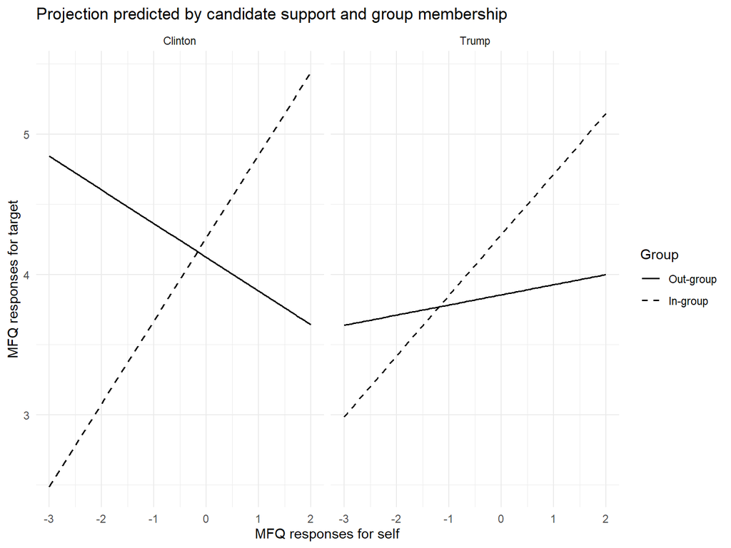

```r
ggplot(initial_study_3way_cand, aes(MFQSelf_c,
                             fit,
                             group = Group,
                             color = Group)) +
  geom_smooth(method = "lm", se = FALSE, size = .7, colour = "black",
              aes(linetype = Group)) +
  facet_wrap(~Candidate) +
  scale_linetype_manual("Group", breaks = c(-.5, .5),
                       labels = c("Out-group", "In-group"),
                       values = c("solid",
                                   "dashed")) +
  theme_minimal() +
  labs(title = "Projection predicted by candidate support and group membership",
       x = "MFQ responses for self",
       y = "MFQ responses for target")
```

# Stereotyping moderator w/ candidate

## Results

```r
stereo_analysis %>%
  select(subid, par_cand) %>%
  unique() %>%
  group_by(par_cand) %>%
  count() %>%
  ungroup() %>%
  mutate(total = sum(n),
         percent = (n/total)*100)
```

```
## # A tibble: 2 x 4
##   par_cand     n total percent
##   <fct>    <int> <int>   <dbl>
## 1 Clinton    458   725    63.2
## 2 Trump      267   725    36.8
```

```r
is_cand <- lmer(MFQTarg ~ MFQSelf_c * MFQStereo_c *
                                    inoutgroup_effects * ident_c * par_cand +
                                    (MFQSelf_c|subid),
                                 data = stereo_analysis)

tab_model(is_cand,
          title = "Projection moderated by stereotyping")
```

Projection moderated by stereotyping

|  | MFQ Targ |  |  |
| --- | --- | --- | --- |
| Predictors | Estimates | CI | p |
| (Intercept) | 4.21 | 4.16 – 4.26 | **<0.001** |
| MFQSelf_c | 0.15 | 0.12 – 0.17 | **<0.001** |
| MFQStereo_c | 0.46 | 0.44 – 0.48 | **<0.001** |
| inoutgroup_effects | 0.12 | 0.01 – 0.22 | **0.026** |
| ident_c | 0.04 | 0.01 – 0.07 | **0.019** |
| par_cand Trump | -0.05 | -0.13 – 0.04 | 0.312 |
| MFQSelf_c * MFQStereo_c | -0.00 | -0.01 – 0.01 | 0.421 |
| MFQSelf_c * inoutgroup_effects | 0.43 | 0.38 – 0.49 | **<0.001** |
| MFQStereo_c * inoutgroup_effects | -0.07 | -0.10 – -0.04 | **<0.001** |
| MFQSelf_c * ident_c | -0.00 | -0.02 – 0.02 | 0.886 |
| MFQStereo_c * ident_c | -0.01 | -0.01 – 0.00 | 0.307 |
| inoutgroup_effects * ident_c | 0.03 | -0.04 – 0.10 | 0.380 |
| MFQSelf_c * par_cand Trump | 0.05 | -0.00 – 0.09 | 0.058 |
| MFQStereo_c * par_cand Trump | -0.03 | -0.05 – 0.00 | 0.052 |
| inoutgroup_effects * par_cand Trump | -0.02 | -0.20 – 0.15 | 0.805 |
| ident_c * par_cand Trump | -0.01 | -0.06 – 0.03 | 0.613 |
| (MFQSelf_c * MFQStereo_c) * inoutgroup_effects | -0.01 | -0.03 – 0.01 | 0.319 |
| (MFQSelf_c * MFQStereo_c) * ident_c | -0.00 | -0.01 – 0.00 | 0.080 |
| (MFQSelf_c *inoutgroup_effects)* ident_c | 0.06 | 0.03 – 0.09 | **0.001** |
| (MFQStereo_c *inoutgroup_effects)* ident_c | -0.02 | -0.04 – 0.00 | 0.086 |
| (MFQSelf_c * MFQStereo_c) * par_cand Trump | -0.01 | -0.02 – 0.00 | 0.152 |
| (MFQSelf_c *inoutgroup_effects)* par_cand Trump | -0.18 | -0.28 – -0.09 | **<0.001** |
| (MFQStereo_c *inoutgroup_effects)* par_cand Trump | -0.19 | -0.24 – -0.13 | **<0.001** |
| (MFQSelf_c * ident_c) * par_cand Trump | -0.01 | -0.03 – 0.02 | 0.464 |
| (MFQStereo_c * ident_c) * par_cand Trump | 0.01 | 0.00 – 0.03 | **0.042** |
| (inoutgroup_effects *ident_c)* par_cand Trump | 0.03 | -0.06 – 0.12 | 0.532 |
| (MFQSelf_c * MFQStereo_c * inoutgroup_effects) * ident_c | -0.02 | -0.03 – -0.01 | **0.001** |
| (MFQSelf_c * MFQStereo_c * inoutgroup_effects) * par_cand Trump | -0.06 | -0.09 – -0.03 | **<0.001** |
| (MFQSelf_c * MFQStereo_c * ident_c) * par_cand Trump | 0.01 | -0.00 – 0.01 | 0.112 |
| (MFQSelf_c *inoutgroup_effects* ident_c) * par_cand Trump | -0.01 | -0.06 – 0.04 | 0.794 |
| (MFQStereo_c *inoutgroup_effects* ident_c) * par_cand Trump | -0.01 | -0.04 – 0.02 | 0.496 |
| (MFQSelf_c * MFQStereo_c * inoutgroup_effects *ident_c)* par_cand Trump | 0.01 | -0.00 – 0.03 | 0.110 |
| Random Effects |  |  |  |
| σ<sup>2</sup> | 1.06 |  |  |
| τ<sub>00</sub> <sub>subid</sub> | 0.19 |  |  |
| τ<sub>11</sub> <sub>subid.MFQSelf_c</sub> | 0.05 |  |  |
| ρ<sub>01</sub> <sub>subid</sub> | 0.05 |  |  |
| ICC | 0.23 |  |  |
| N <sub>subid</sub> | 725 |  |  |
| Observations | 21514 |  |  |
| Marginal R<sup>2</sup> / Conditional R<sup>2</sup> | 0.431 / 0.562 |  |  |

When we include who the participant voted for with stereotyping as well, we still have the main effect from above. Now, the interaction between target group and in-group identification is significant. There is also an interaction between target group (in or out) and who the participant voted for. However, an interaction between target group, degree of in-group identification, and who they voted for is not significant. There are other significant interactions including stereotyping, but, since we only included it as a moderator to see if the relationship persisted, I didn’t go through them thoroughly.

## Plot: Projection by group x cand

```r
is_group_cand <- effect(term = "MFQSelf_c:inoutgroup_effects:par_cand",
                             xlevels = list(inoutgroup_effects = c(-.5,.5),
                                            par_cand = c("Clinton", "Trump")),
                             mod = is_cand)

is_group_cand <- as.data.frame(is_group_cand)

is_group_cand$Group <- as.factor(is_group_cand$inoutgroup_effects)
```

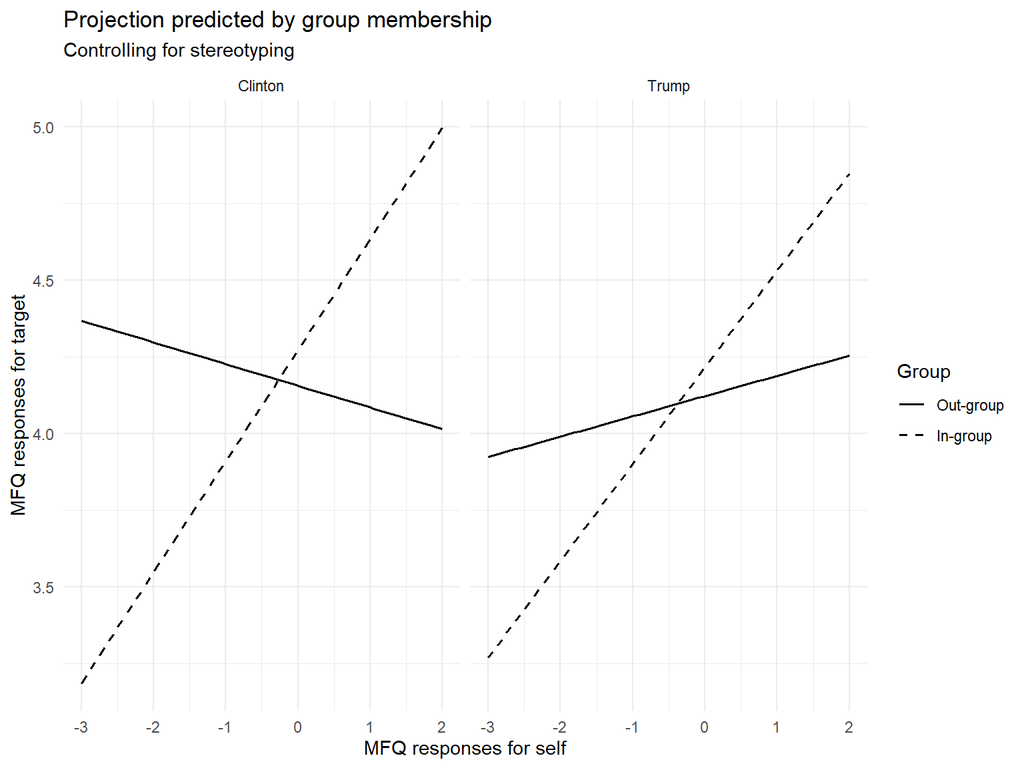

```r
ggplot(is_group_cand, aes(MFQSelf_c,
                               fit,
                               group = Group,
                               color = Group)) +
  geom_smooth(method = "lm", se = FALSE, size = .7, colour = "black",
              aes(linetype = Group)) +
  facet_wrap(~par_cand)+
  scale_linetype_manual("Group", breaks = c(-.5, .5),
                       labels = c("Out-group", "In-group"),
                       values = c("solid",
                                  "dashed")) +
  theme_minimal() +
  labs(title = "Projection predicted by group membership",
       subtitle = "Controlling for stereotyping",
       x = "MFQ responses for self",
       y = "MFQ responses for target")
```

Clinton supporters counter project and Trump supporters do not. I’ve checked this a lot and it seems to be correct, I must have messed up in my first year when I analyzed it…

## Plot: Projection by target x ident

```r
is_3way_cand <- effect(term = "MFQSelf_c:inoutgroup_effects:ident_c",
                           xlevels = list(ident_c = c(-1.78, 0, 1.78),
                                         inoutgroup_effects = c(-.5,.5)),
                           mod = is_cand)

is_3way_cand <- as.data.frame(is_3way_cand)

is_3way_cand$Group <- as.factor(is_3way_cand$inoutgroup_effects)
is_3way_cand$Identification <- as.factor(is_3way_cand$ident_c)

ident_label <- c("-1.78" = "Low identification \n (1 SD below)",
                 "0" = "Average identification",
                 "1.78" = "High identificatiion \n(1 SD above)")
```

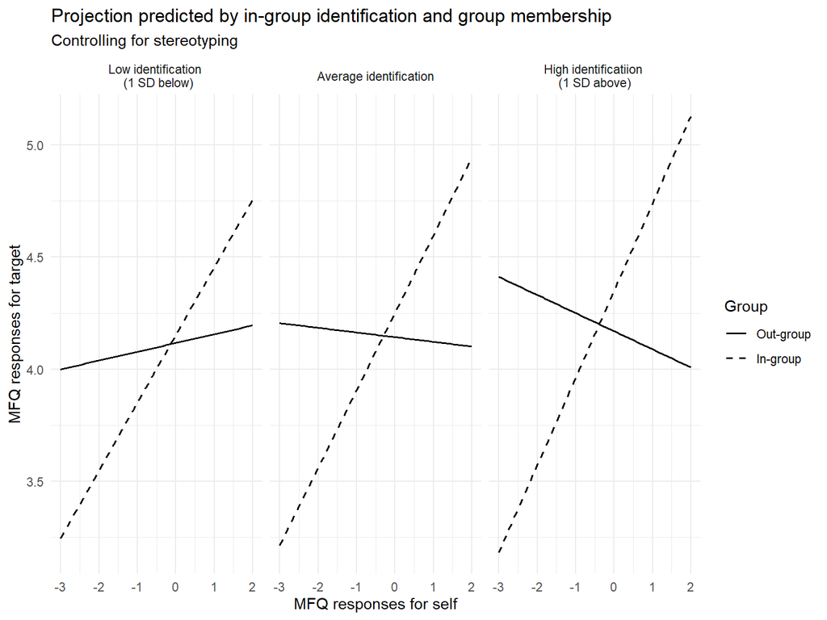

```r
ggplot(is_3way_cand, aes(MFQSelf_c,
                             fit,
                             group = Group,
                             color = Group)) +
  geom_smooth(method = "lm", se = FALSE, size = .7, colour = "black",
              aes(linetype = Group)) +
  facet_wrap(~Identification, labeller =
               labeller(Identification = ident_label)) +
  scale_linetype_manual("Group", breaks = c(-.5, .5),
                       labels = c("Out-group", "In-group"),
                       values = c("solid",
                                   "dashed")) +
  theme_minimal() +
  labs(title = "Projection predicted by in-group identification and group membership",
       subtitle = "Controlling for stereotyping",
       x = "MFQ responses for self",
       y = "MFQ responses for target")
```

## Plot: Projection x group

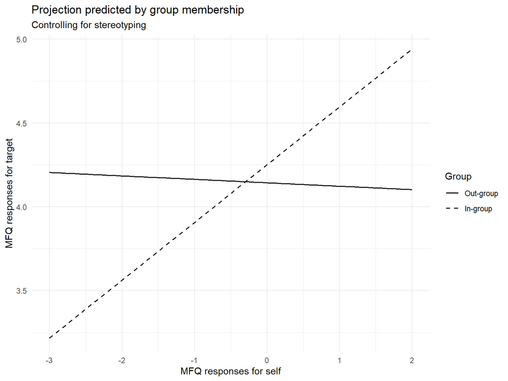

```r
ggplot(is_group_cand, aes(MFQSelf_c,
                               fit,
                               group = Group,
                               color = Group)) +
  geom_smooth(method = "lm", se = FALSE, size = .7, colour = "black",
              aes(linetype = Group)) +
  scale_linetype_manual("Group", breaks = c(-.5, .5),
                       labels = c("Out-group", "In-group"),
                       values = c("solid",
                                  "dashed")) +
  theme_minimal() +
  labs(title = "Projection predicted by group membership",
       subtitle = "Controlling for stereotyping",
       x = "MFQ responses for self",
       y = "MFQ responses for target")
```

## Plot: Stereotyping by group

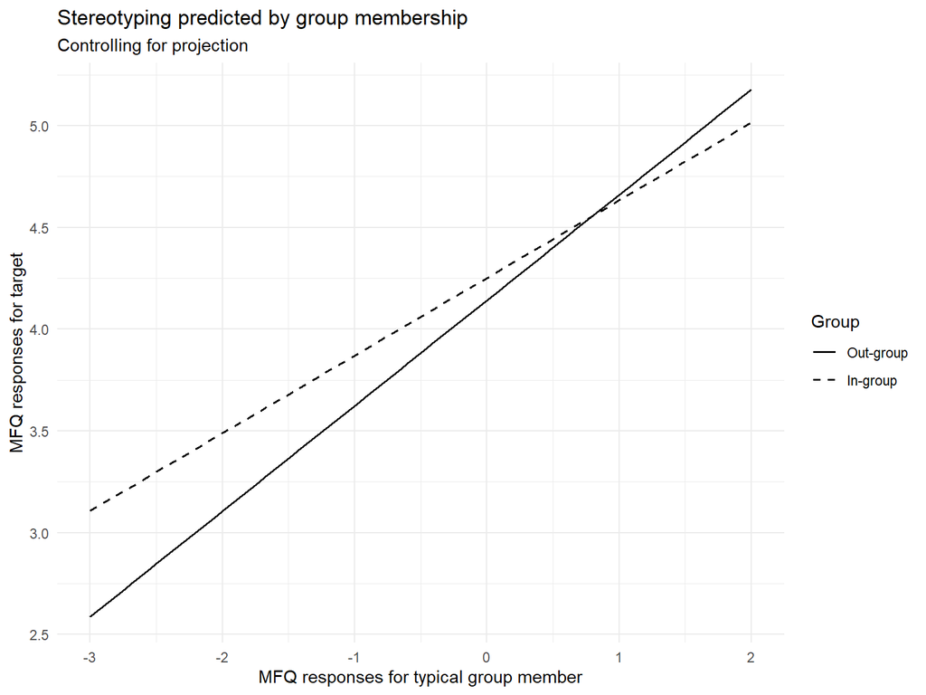

```r
is_group_stereo <- effect(term = "MFQStereo_c:inoutgroup_effects",
                             xlevels = list(inoutgroup_effects = c(-.5,.5)),
                             mod = is_cand)

is_group_stereo <- as.data.frame(is_group_stereo)

is_group_stereo$Group <- as.factor(is_group_stereo$inoutgroup_effects)

ggplot(is_group_stereo, aes(MFQStereo_c,
                               fit,
                               group = Group,
                               color = Group)) +
  geom_smooth(method = "lm", se = FALSE, size = .7, colour = "black",
              aes(linetype = Group)) +
  scale_linetype_manual("Group", breaks = c(-.5, .5),
                       labels = c("Out-group", "In-group"),
                       values = c("solid",
                                  "dashed")) +
  theme_minimal() +
  labs(title = "Stereotyping predicted by group membership",
       subtitle = "Controlling for projection",
       x = "MFQ responses for typical group member",
       y = "MFQ responses for target")
```

People stereotype out-group more than in-group.

## Plot: Stereotyping by cand

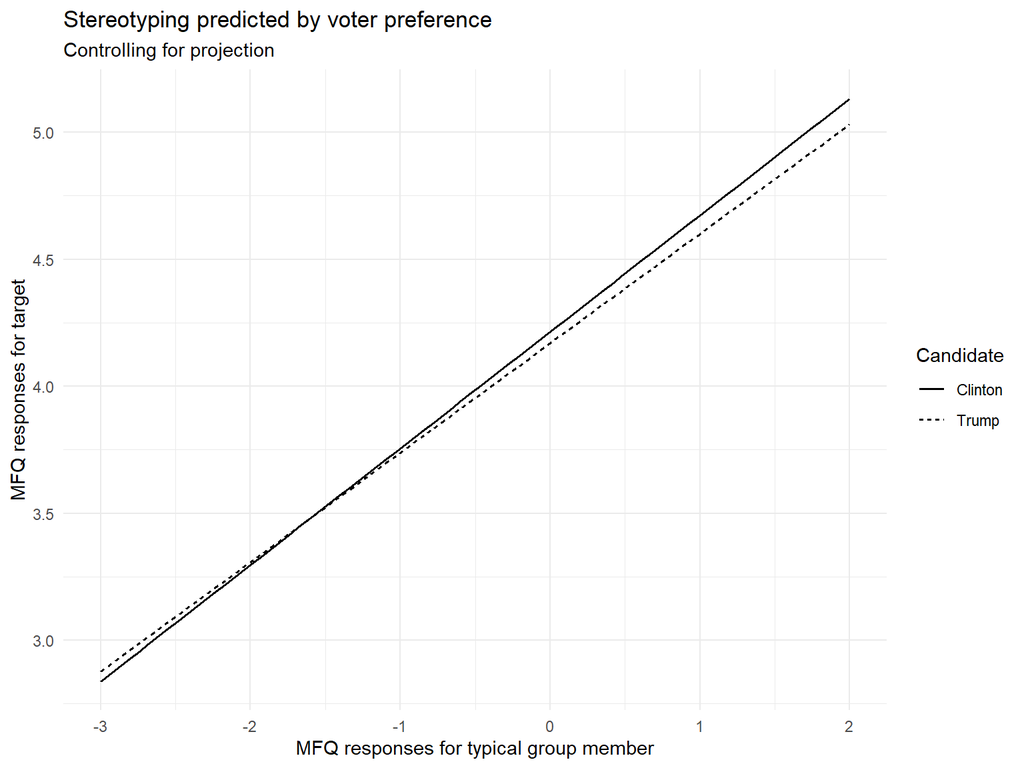

```r
is_cand_stereo <- effect(term = "MFQStereo_c:par_cand",
                             xlevels = list(par_cand = c("Clinton", "Trump")),
                             mod = is_cand)

is_cand_stereo <- as.data.frame(is_cand_stereo)

is_cand_stereo$Candidate <- as.factor(is_cand_stereo$par_cand)

ggplot(is_cand_stereo, aes(MFQStereo_c,
                               fit,
                               group = Candidate,
                               color = Candidate)) +
  geom_smooth(method = "lm", se = FALSE, size = .7, colour = "black",
              aes(linetype = Candidate)) +
  theme_minimal() +
  labs(title = "Stereotyping predicted by voter preference",
       subtitle = "Controlling for projection",
       x = "MFQ responses for typical group member",
       y = "MFQ responses for target")
```

Clinton supporters stereotype more than Trump supporters.

## Plot: Stereotyping by group x cand

```r
is_group_cand_stereo <- effect(term = "MFQStereo_c:inoutgroup_effects:par_cand",
                             xlevels = list(inoutgroup_effects = c(-.5,.5),
                                            par_cand = c("Clinton", "Trump")),
                             mod = is_cand)

is_group_cand_stereo <- as.data.frame(is_group_cand_stereo)

is_group_cand_stereo$Group <- as.factor(is_group_cand_stereo$inoutgroup_effects)
```

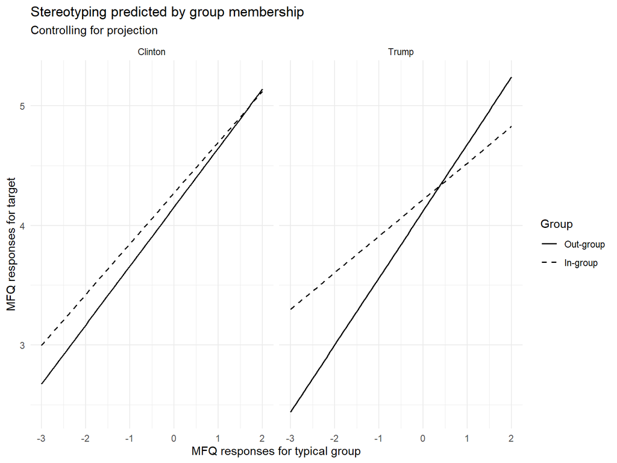

```r
ggplot(is_group_cand_stereo, aes(MFQStereo_c,
                               fit,
                               group = Group,
                               color = Group)) +
  geom_smooth(method = "lm", se = FALSE, size = .7, colour = "black",
              aes(linetype = Group)) +
  facet_wrap(~par_cand)+
  scale_linetype_manual("Group", breaks = c(-.5, .5),
                       labels = c("Out-group", "In-group"),
                       values = c("solid",
                                  "dashed")) +
  theme_minimal() +
  labs(title = "Stereotyping predicted by group membership",
       subtitle = "Controlling for projection",
       x = "MFQ responses for typical group",
       y = "MFQ responses for target")
```

Trump supporters stereotype the out-group more than their in-group, while Clinton supporters stereotype them to a similar extent.

## Plot: Stereotyping by group x ident

```r
is_3way_cand_stereo <- effect(term = "MFQStereo_c:inoutgroup_effects:ident_c",
                           xlevels = list(ident_c = c(-1.78, 0, 1.78),
                                         inoutgroup_effects = c(-.5,.5)),
                           mod = is_cand)

is_3way_cand_stereo  <- as.data.frame(is_3way_cand_stereo)

is_3way_cand_stereo$Group <- as.factor(is_3way_cand_stereo$inoutgroup_effects)
is_3way_cand_stereo$Identification <- as.factor(is_3way_cand_stereo$ident_c)

ident_label <- c("-1.78" = "Low identification \n (1 SD below)",
                 "0" = "Average identification",
                 "1.78" = "High identificatiion \n(1 SD above)")
```

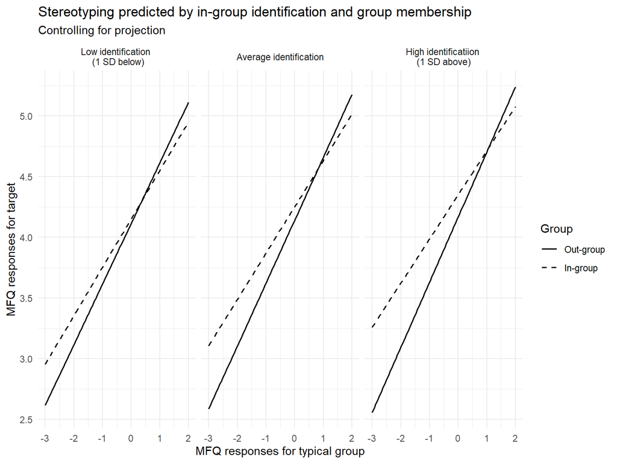

```r
ggplot(is_3way_cand_stereo, aes(MFQStereo_c,
                             fit,
                             group = Group,
                             color = Group)) +
  geom_smooth(method = "lm", se = FALSE, size = .7, colour = "black",
              aes(linetype = Group)) +
  facet_wrap(~Identification, labeller =
               labeller(Identification = ident_label)) +
  scale_linetype_manual("Group", breaks = c(-.5, .5),
                       labels = c("Out-group", "In-group"),
                       values = c("solid",
                                   "dashed")) +
  theme_minimal() +
  labs(title = "Stereotyping predicted by in-group identification and group membership",
       subtitle = "Controlling for projection",
       x = "MFQ responses for typical group",
       y = "MFQ responses for target")
```

## Plot: Projection by stereo x group

```r
describe(stereo_analysis$MFQStereo_c)
```

```
##    vars     n mean   sd median trimmed  mad   min  max range  skew kurtosis
## X1    1 21514    0 1.67   0.15    0.09 1.48 -2.85 2.15     5 -0.32    -1.11
##      se
## X1 0.01
```

```r
is_stereo_proj_group <- effect(term = "MFQSelf_c:MFQStereo_c:inoutgroup_effects",
                           xlevels = list(MFQStereo_c = c(-1.48, 0, 1.48),
                                         inoutgroup_effects = c(-.5,.5)),
                           mod = is_cand)

is_stereo_proj_group  <- as.data.frame(is_stereo_proj_group)

is_stereo_proj_group$Group <- as.factor(is_stereo_proj_group$inoutgroup_effects)
is_stereo_proj_group$Stereotyping <- as.factor(is_stereo_proj_group$MFQStereo_c)

stereo_label <- c("-1.48" = "Less stereotyping \n (1 SD below)",
                 "0" = "Average stereotyping",
                 "1.48" = "High stereotyping \n(1 SD above)")
```

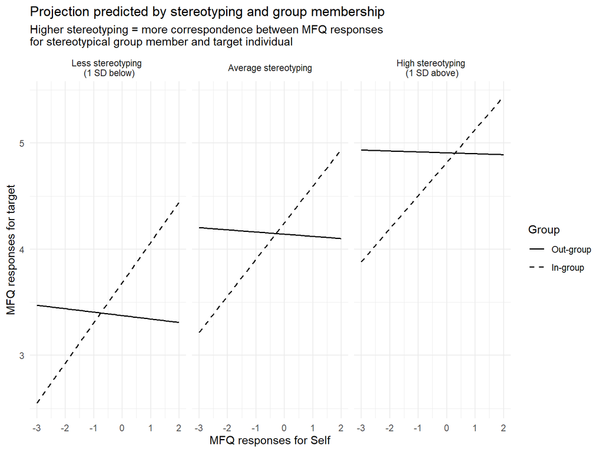

```r
ggplot(is_stereo_proj_group, aes(MFQSelf_c,
                             fit,
                             group = Group,
                             color = Group)) +
  geom_smooth(method = "lm", se = FALSE, size = .7, colour = "black",
              aes(linetype = Group)) +
  facet_wrap(~Stereotyping, labeller =
               labeller(Stereotyping = stereo_label)) +
  scale_linetype_manual("Group", breaks = c(-.5, .5),
                       labels = c("Out-group", "In-group"),
                       values = c("solid",
                                   "dashed")) +
  theme_minimal() +
  labs(title = "Projection predicted by stereotyping and group membership",
       subtitle = "Higher stereotyping = more correspondence between MFQ responses \nfor stereotypical group member and target individual",
       x = "MFQ responses for Self",
       y = "MFQ responses for target")
```

## Plot: Projection by stereo x ident

```r
is_stereo_proj_ident <- effect(term = "MFQSelf_c:MFQStereo_c:ident_c",
                           xlevels = list(MFQStereo_c = c(-1.48, 0, 1.48),
                                         ident_c = c(-1.78, 0, 1.78)),
                           mod = is_cand)

is_stereo_proj_ident  <- as.data.frame(is_stereo_proj_ident)

is_stereo_proj_ident$Identification <- as.factor(is_stereo_proj_ident$ident_c)
is_stereo_proj_ident$Stereotyping <- as.factor(is_stereo_proj_ident$MFQStereo_c)

stereo_label <- c("-1.48" = "Less stereotyping \n (1 SD below)",
                 "0" = "Average stereotyping",
                 "1.48" = "High stereotyping \n(1 SD above)")
```

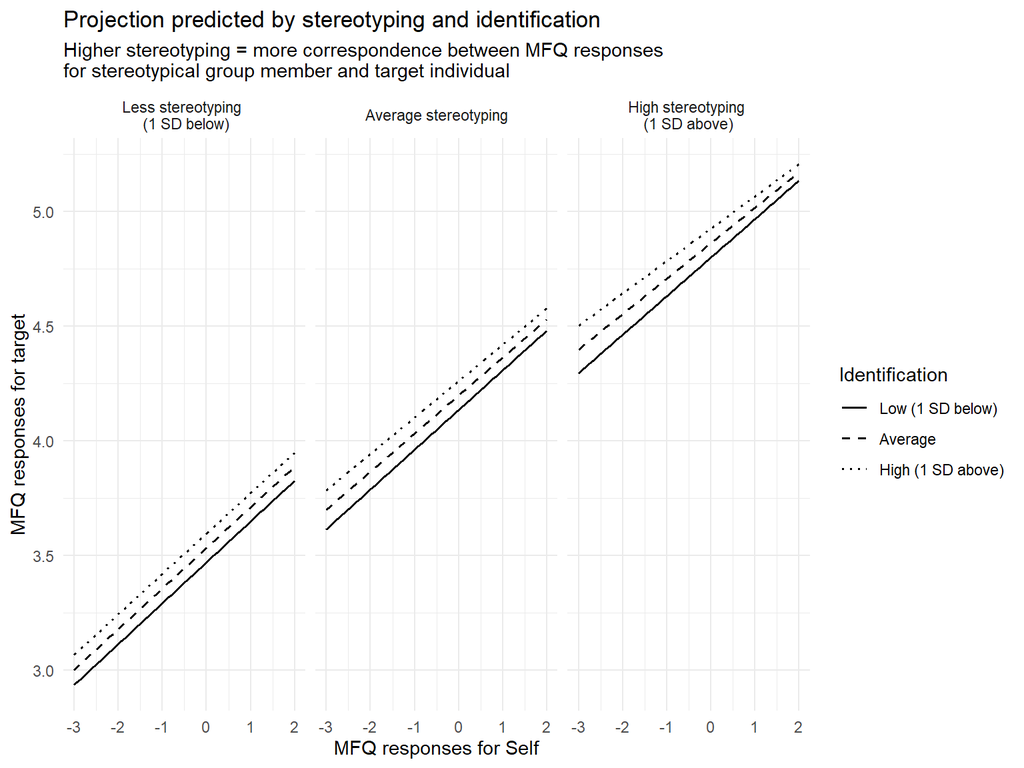

```r
ggplot(is_stereo_proj_ident, aes(MFQSelf_c,
                             fit,
                             group = Identification,
                             color = Identification)) +
  geom_smooth(method = "lm", se = FALSE, size = .7, colour = "black",
              aes(linetype = Identification)) +
  facet_wrap(~Stereotyping, labeller =
               labeller(Stereotyping = stereo_label)) +
  scale_linetype_manual("Identification", breaks = c(-1.78, 0, 1.78),
                       labels = c("Low (1 SD below)",
                                  "Average",
                                  "High (1 SD above)"),
                       values = c("solid",
                                   "dashed",
                                  "dotted")) +
  theme_minimal() +
  labs(title = "Projection predicted by stereotyping and identification",
       subtitle = "Higher stereotyping = more correspondence between MFQ responses \nfor stereotypical group member and target individual",
       x = "MFQ responses for Self",
       y = "MFQ responses for target")
```

##Plot: Projection by stereo x group x ident

```r
is_stereo_proj_ident_group <- effect(term = "MFQSelf_c:MFQStereo_c:inoutgroup_effects:ident_c",
                           xlevels = list(MFQStereo_c = c(-1.48, 0, 1.48),
                                         ident_c = c(-1.78, 0, 1.78),
                                         inoutgroup_effects = c(-.5,.5)),
                           mod = is_cand)

is_stereo_proj_ident_group  <- as.data.frame(is_stereo_proj_ident_group)

is_stereo_proj_ident_group$Identification <- as.factor(is_stereo_proj_ident_group$ident_c)
is_stereo_proj_ident_group$Stereotyping <- as.factor(is_stereo_proj_ident_group$MFQStereo_c)
is_stereo_proj_ident_group$Group <- as.factor(is_stereo_proj_ident_group$inoutgroup_effects)

stereo_label <- c("-1.48" = "Less stereotyping \n (1 SD below)",
                 "0" = "Average stereotyping",
                 "1.48" = "High stereotyping \n(1 SD above)")
```

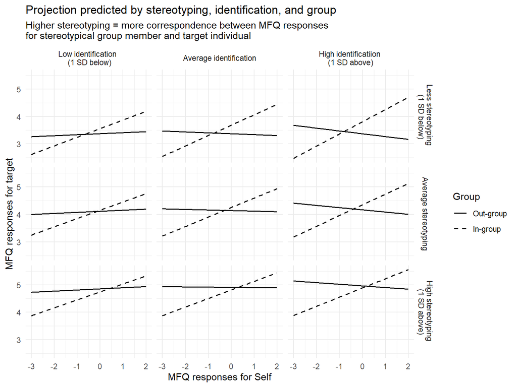

```r
ggplot(is_stereo_proj_ident_group, aes(MFQSelf_c,
                             fit,
                             group = Group,
                             color = Group)) +
  geom_smooth(method = "lm", se = FALSE, size = .7, colour = "black",
              aes(linetype = Group)) +
  facet_grid(Stereotyping ~ Identification, labeller =
               labeller(Identification = ident_label, Stereotyping = stereo_label)) +
    scale_linetype_manual("Group", breaks = c(-.5, .5),
                       labels = c("Out-group", "In-group"),
                       values = c("solid",
                                   "dashed")) +
  theme_minimal() +
  labs(title = "Projection predicted by stereotyping, identification, and group",
       subtitle = "Higher stereotyping = more correspondence between MFQ responses \nfor stereotypical group member and target individual",
       x = "MFQ responses for Self",
       y = "MFQ responses for target")
```

## Plot: Projection x stereo x ident x cand

```r
is_stereo_proj_ident_cand <- effect(term = "MFQSelf_c:MFQStereo_c:ident_c:par_cand",
                           xlevels = list(MFQStereo_c = c(-1.48, 0, 1.48),
                                         ident_c = c(-1.78, 0, 1.78),
                                         par_cand = c("Clinton", "Trump")),
                           mod = is_cand)

is_stereo_proj_ident_cand  <- as.data.frame(is_stereo_proj_ident_cand)

is_stereo_proj_ident_cand$Identification <- as.factor(is_stereo_proj_ident_cand$ident_c)
is_stereo_proj_ident_cand$Stereotyping <- as.factor(is_stereo_proj_ident_cand$MFQStereo_c)
is_stereo_proj_ident_cand$Candidate <- as.factor(is_stereo_proj_ident_cand$par_cand)

stereo_label <- c("-1.48" = "Less stereotyping \n (1 SD below)",
                 "0" = "Average stereotyping",
                 "1.48" = "High stereotyping \n(1 SD above)")
```

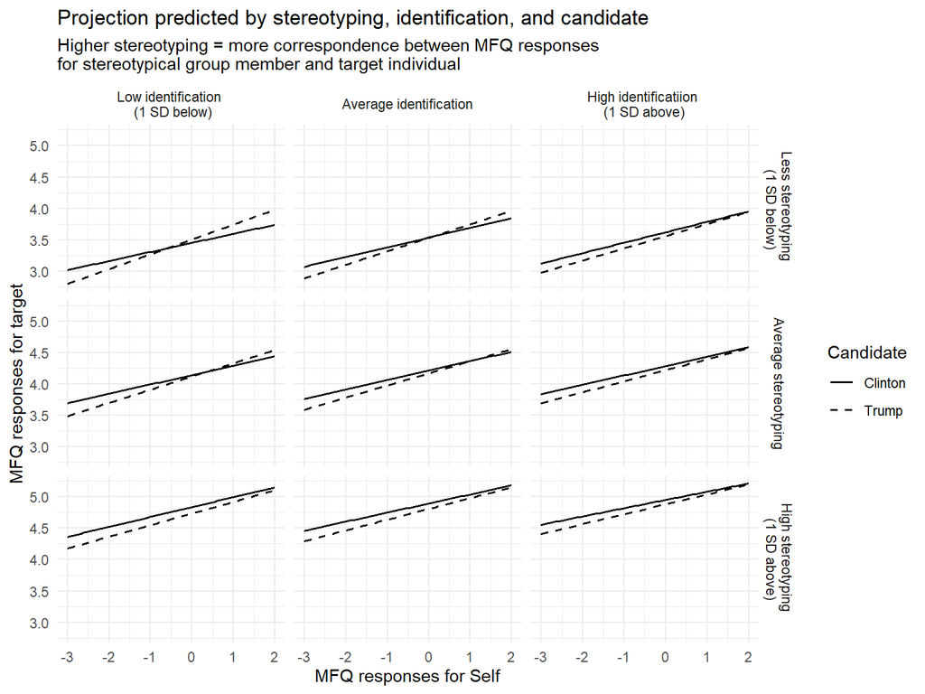

```r
ggplot(is_stereo_proj_ident_cand, aes(MFQSelf_c,
                             fit,
                             group = Candidate,
                             color = Candidate)) +
  geom_smooth(method = "lm", se = FALSE, size = .7, colour = "black",
              aes(linetype = Candidate)) +
  facet_grid(Stereotyping ~ Identification, labeller =
               labeller(Identification = ident_label, Stereotyping = stereo_label)) +
    scale_linetype_manual("Candidate", breaks = c("Clinton", "Trump"),
                       values = c("solid",
                                   "dashed")) +
  theme_minimal() +
  labs(title = "Projection predicted by stereotyping, identification, and candidate",
       subtitle = "Higher stereotyping = more correspondence between MFQ responses \nfor stereotypical group member and target individual",
       x = "MFQ responses for Self",
       y = "MFQ responses for target")
```

## Plot: Projection by stereo x group x cand

```r
is_stereo_proj_inout_cand <- effect(term = "MFQSelf_c:MFQStereo_c:inoutgroup_effects:par_cand",
                           xlevels = list(MFQStereo_c = c(-1.48, 0, 1.48),
                                         inoutgroup_effects = c(-.5,.5),
                                         par_cand = c("Clinton", "Trump")),
                           mod = is_cand)

is_stereo_proj_inout_cand  <- as.data.frame(is_stereo_proj_inout_cand)

is_stereo_proj_inout_cand$Group <- as.factor(is_stereo_proj_inout_cand$inoutgroup_effects)
is_stereo_proj_inout_cand$Stereotyping <- as.factor(is_stereo_proj_inout_cand$MFQStereo_c)
is_stereo_proj_inout_cand$Candidate <- as.factor(is_stereo_proj_inout_cand$par_cand)

stereo_label <- c("-1.48" = "Less stereotyping \n (1 SD below)",
                 "0" = "Average stereotyping",
                 "1.48" = "High stereotyping \n(1 SD above)")
group_label <- c("-0.5" = "Out-group",
                 "0.5" = "In-group")
```

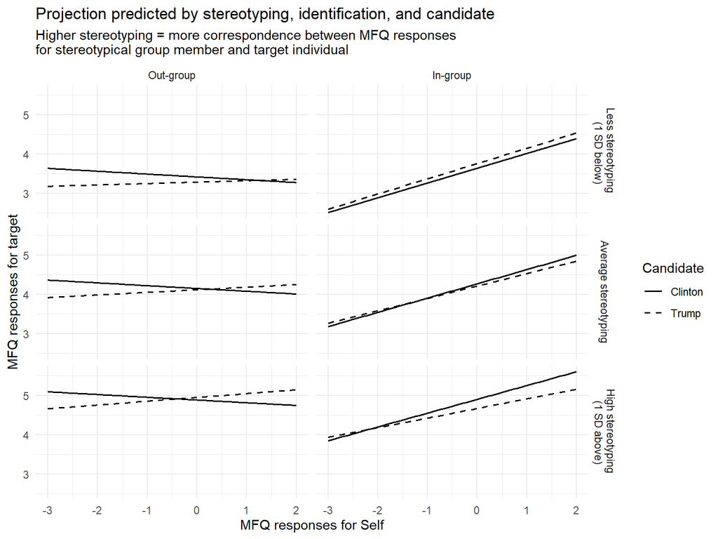

```r
ggplot(is_stereo_proj_inout_cand, aes(MFQSelf_c,
                             fit,
                             group = Candidate,
                             color = Candidate)) +
  geom_smooth(method = "lm", se = FALSE, size = .7, colour = "black",
              aes(linetype = Candidate)) +
  facet_grid(Stereotyping ~ Group, labeller =
               labeller(Group = group_label, Stereotyping = stereo_label)) +
    scale_linetype_manual("Candidate", breaks = c("Clinton", "Trump"),
                       values = c("solid",
                                   "dashed")) +
  theme_minimal() +
  labs(title = "Projection predicted by stereotyping, identification, and candidate",
       subtitle = "Higher stereotyping = more correspondence between MFQ responses \nfor stereotypical group member and target individual",
       x = "MFQ responses for Self",
       y = "MFQ responses for target")
```

## Plot: Projection by stereo x group x ident x cand

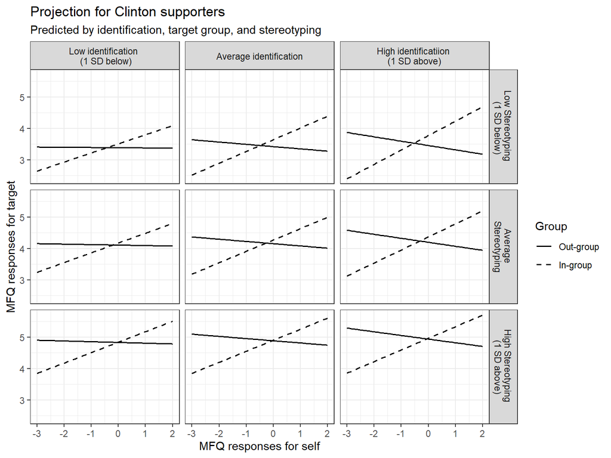

```r
is_5way <- effect(term = "MFQSelf_c:MFQStereo_c:inoutgroup_effects:ident_c:par_cand",
                           xlevels = list(ident_c = c(-1.78, 0, 1.78),
                                         inoutgroup_effects = c(-.5,.5),
                                         MFQStereo_c = c(-1.48, 0, 1.48),
                                         par_cand = c("Clinton", "Trump")),
                           mod = is_cand)

is_5way <- as.data.frame(is_5way)

is_5way$Group <- as.factor(is_5way$inoutgroup_effects)
is_5way$Identification <- as.factor(is_5way$ident_c)
is_5way$Stereotyping <- as.factor(is_5way$MFQStereo_c)
is_5way$Candidate <- as.factor(is_5way$par_cand)

#Plot for Clinton supporters - decided to do two two-ways because I think It will be cleaner?

clinton_5way <- is_5way %>%
  filter(Candidate == "Clinton")

stereo_label <- c("-1.48" = "Low Stereotyping \n (1 SD below)",
                 "0" = "Average \nStereotyping",
                 "1.48" = "High Stereotyping \n(1 SD above)")

ggplot(clinton_5way, aes(MFQSelf_c,
                             fit,
                             group = Group,
                             color = Group)) +
  geom_smooth(method = "lm", se = FALSE, size = .7, colour = "black",
              aes(linetype = Group)) +
  facet_grid(Stereotyping ~ Identification, labeller =
               labeller(Identification = ident_label, Stereotyping = stereo_label)) +
  scale_linetype_manual("Group", breaks = c(-.5, .5),
                       labels = c("Out-group", "In-group"),
                       values = c("solid",
                                   "dashed")) +
  theme_bw() +
  labs(title = "Projection for Clinton supporters",
       subtitle = "Predicted by identification, target group, and stereotyping",
       x = "MFQ responses for self",
       y = "MFQ responses for target")
```

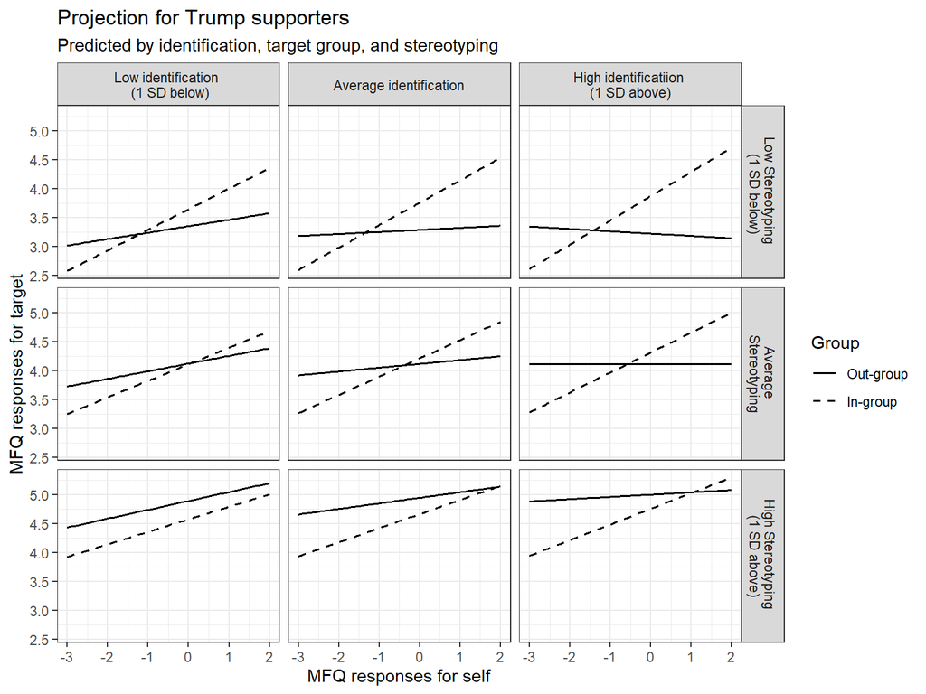

```r
#Plot for trump supporters

trump_5way <- is_5way %>%
  filter(Candidate != "Clinton")

stereo_label <- c("-1.48" = "Low Stereotyping \n (1 SD below)",
                 "0" = "Average \nStereotyping",
                 "1.48" = "High Stereotyping \n(1 SD above)")

ggplot(trump_5way, aes(MFQSelf_c,
                             fit,
                             group = Group,
                             color = Group)) +
  geom_smooth(method = "lm", se = FALSE, size = .7, colour = "black",
              aes(linetype = Group)) +
  facet_grid(Stereotyping ~ Identification, labeller =
               labeller(Identification = ident_label, Stereotyping = stereo_label)) +
  scale_linetype_manual("Group", breaks = c(-.5, .5),
                       labels = c("Out-group", "In-group"),
                       values = c("solid",
                                   "dashed")) +
  theme_bw() +
  labs(title = "Projection for Trump supporters",
       subtitle = "Predicted by identification, target group, and stereotyping",
       x = "MFQ responses for self",
       y = "MFQ responses for target")
```

# Diff score analysis between nomothetic and idiographic stereo

## Results

```r
nom_v_id_data <- stereo_analysis %>%
  group_by(MFQ_Number, par_cand, inoutgroup_effects) %>%
  mutate(stereo_nomothetic = mean(MFQStereo)) %>%
  ungroup() %>%
  group_by(subid) %>%
  mutate(stereo_diff = abs(MFQStereo - stereo_nomothetic))

nom_v_id_model <- lmer(MFQTarg ~ MFQSelf_c * stereo_diff *
                                    inoutgroup_effects * ident_c * par_cand +
                                    (MFQSelf_c|subid),
                                 data = nom_v_id_data)

tab_model(nom_v_id_model,
          title = "Nomothetic/idiographic difference score predicting projection")
```

Nomothetic/idiographic difference score predicting projection

|  | MFQ Targ |  |  |
| --- | --- | --- | --- |
| Predictors | Estimates | CI | p |
| (Intercept) | 4.31 | 4.24 – 4.39 | **<0.001** |
| MFQSelf_c | 0.18 | 0.13 – 0.22 | **<0.001** |
| stereo_diff | -0.11 | -0.15 – -0.08 | **<0.001** |
| inoutgroup_effects | 0.18 | 0.03 – 0.33 | **0.019** |
| ident_c | 0.01 | -0.04 – 0.06 | 0.694 |
| par_cand Trump | -0.10 | -0.22 – 0.03 | 0.143 |
| MFQSelf_c * stereo_diff | -0.00 | -0.02 – 0.01 | 0.667 |
| MFQSelf_c * inoutgroup_effects | 0.83 | 0.75 – 0.91 | **<0.001** |
| stereo_diff * inoutgroup_effects | -0.06 | -0.13 – 0.00 | 0.053 |
| MFQSelf_c * ident_c | -0.01 | -0.04 – 0.02 | 0.468 |
| stereo_diff * ident_c | 0.03 | 0.01 – 0.05 | **0.001** |
| inoutgroup_effects * ident_c | 0.03 | -0.07 – 0.12 | 0.588 |
| MFQSelf_c * par_cand Trump | 0.04 | -0.03 – 0.12 | 0.257 |
| stereo_diff * par_cand Trump | -0.01 | -0.06 – 0.05 | 0.833 |
| inoutgroup_effects * par_cand Trump | 0.33 | 0.07 – 0.58 | **0.012** |
| ident_c * par_cand Trump | -0.05 | -0.12 – 0.02 | 0.143 |
| (MFQSelf_c * stereo_diff) * inoutgroup_effects | -0.01 | -0.05 – 0.03 | 0.591 |
| (MFQSelf_c * stereo_diff) * ident_c | 0.00 | -0.01 – 0.02 | 0.474 |
| (MFQSelf_c *inoutgroup_effects)* ident_c | 0.06 | 0.01 – 0.11 | **0.021** |
| (stereo_diff *inoutgroup_effects)* ident_c | 0.03 | -0.01 – 0.07 | 0.178 |
| (MFQSelf_c * stereo_diff) * par_cand Trump | 0.03 | -0.01 – 0.06 | 0.101 |
| (MFQSelf_c *inoutgroup_effects)* par_cand Trump | -0.57 | -0.71 – -0.42 | **<0.001** |
| (stereo_diff *inoutgroup_effects)* par_cand Trump | 0.00 | -0.11 – 0.11 | 0.989 |
| (MFQSelf_c * ident_c) * par_cand Trump | -0.02 | -0.06 – 0.02 | 0.280 |
| (stereo_diff * ident_c) * par_cand Trump | 0.00 | -0.03 – 0.03 | 0.796 |
| (inoutgroup_effects *ident_c)* par_cand Trump | 0.13 | -0.01 – 0.26 | 0.075 |
| (MFQSelf_c * stereo_diff * inoutgroup_effects) * ident_c | 0.02 | 0.00 – 0.05 | **0.038** |
| (MFQSelf_c * stereo_diff * inoutgroup_effects) * par_cand Trump | 0.08 | 0.01 – 0.15 | **0.023** |
| (MFQSelf_c * stereo_diff * ident_c) * par_cand Trump | 0.01 | -0.01 – 0.02 | 0.460 |
| (MFQSelf_c *inoutgroup_effects* ident_c) * par_cand Trump | 0.03 | -0.05 – 0.10 | 0.469 |
| (stereo_diff *inoutgroup_effects* ident_c) * par_cand Trump | -0.06 | -0.11 – 0.00 | 0.052 |
| (MFQSelf_c * stereo_diff * inoutgroup_effects *ident_c)* par_cand Trump | -0.02 | -0.05 – 0.01 | 0.214 |
| Random Effects |  |  |  |
| σ<sup>2</sup> | 1.40 |  |  |
| τ<sub>00</sub> <sub>subid</sub> | 0.34 |  |  |
| τ<sub>11</sub> <sub>subid.MFQSelf_c</sub> | 0.09 |  |  |
| ρ<sub>01</sub> <sub>subid</sub> | 0.14 |  |  |
| ICC | 0.29 |  |  |
| N <sub>subid</sub> | 725 |  |  |
| Observations | 21514 |  |  |
| Marginal R<sup>2</sup> / Conditional R<sup>2</sup> | 0.212 / 0.440 |  |  |

## Plots

```r
nvi_projxdiff <- effect(term = "MFQSelf_c:stereo_diff",
                             xlevels = list(stereo_diff = c(0,1.0,2.0,3.0,4.0)),
                             mod = nom_v_id_model)

nvi_projxdiff <- as.data.frame(nvi_projxdiff)

nvi_projxdiff$stereo_diff <- as.factor(nvi_projxdiff$stereo_diff)
```

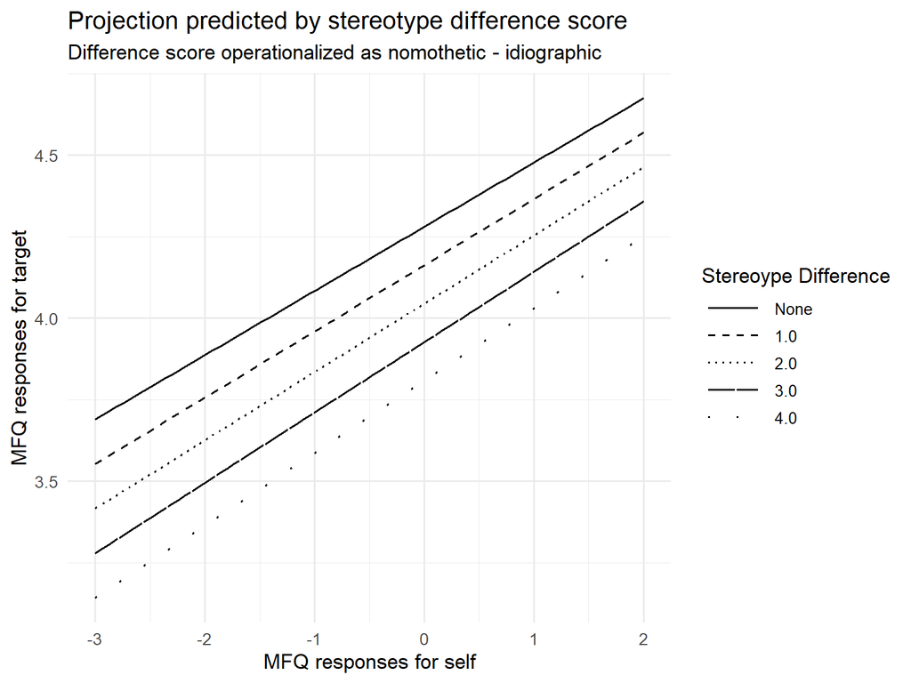

```r
ggplot(nvi_projxdiff, aes(MFQSelf_c,
                               fit,
                               group = stereo_diff,
                               color = stereo_diff)) +
  geom_smooth(method = "lm", se = FALSE, size = .7, colour = "black",
              aes(linetype = stereo_diff)) +
  scale_linetype_manual("Stereoype Difference", breaks = c(0,1.0,2.0,3.0,4.0),
                       labels = c("None",
                                  "1.0",
                                  "2.0",
                                  "3.0",
                                  "4.0"),
                       values = c("solid",
                                  "dashed",
                                  "dotted",
                                  "F1",
                                  "1F")) +
  theme_minimal(base_size = 13) +
  labs(title = "Projection predicted by stereotype difference score",
       subtitle = "Difference score operationalized as nomothetic - idiographic ",
       x = "MFQ responses for self",
       y = "MFQ responses for target") +
  theme(legend.text = element_text(size = 10),
        legend.key.width = unit(1.4, "cm"))
```

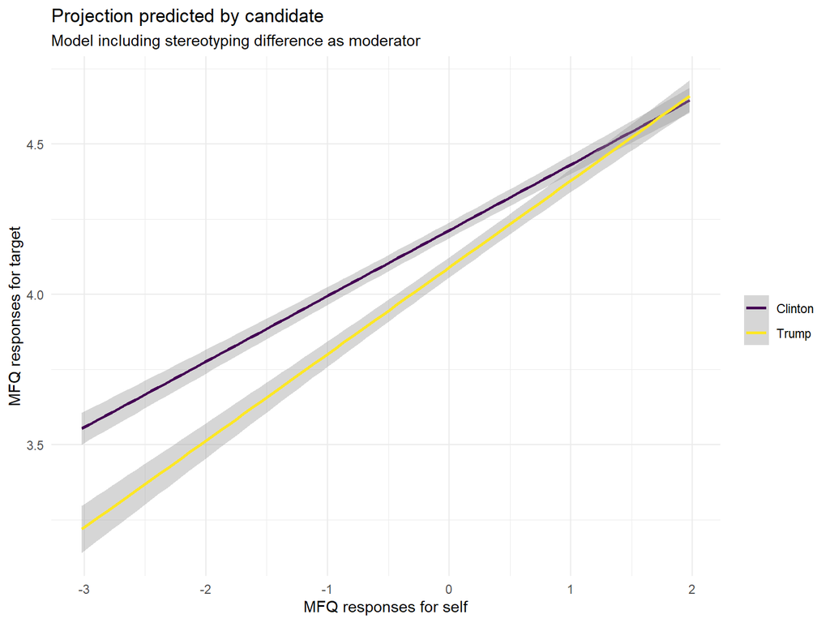

```r
ggplot(nom_v_id_data, aes(MFQSelf_c, MFQTarg, color = par_cand)) +
  geom_smooth(method = "lm",
              se = TRUE) +
  theme_minimal() +
  scale_color_viridis_d() +
  theme(legend.title=element_blank()) +
  labs(title = "Projection predicted by candidate",
       subtitle = "Model including stereotyping difference as moderator",
       x = "MFQ responses for self",
       y = "MFQ responses for target")
```

Trump supporters project more than Clinton supporters, but neither counter project across moderators.

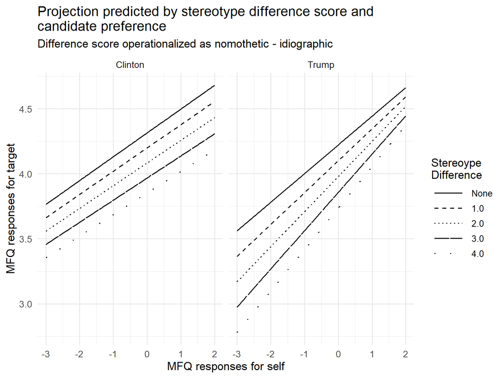

```r
nvi_projxdiffxcand <- effect(term =
                                "MFQSelf_c:stereo_diff:par_cand",
                             xlevels = list(stereo_diff = c(0,1.0,2.0,3.0,4.0),
                                            par_cand = c("Clinton", "Trump")),
                             mod = nom_v_id_model)

nvi_projxdiffxcand<- as.data.frame(nvi_projxdiffxcand)

nvi_projxdiffxcand$stereo_diff <- as.factor(nvi_projxdiffxcand$stereo_diff)
nvi_projxdiffxcand$cand <- as.factor(nvi_projxdiffxcand$par_cand)

ggplot(nvi_projxdiffxcand, aes(MFQSelf_c,
                               fit,
                               group = stereo_diff,
                               color = stereo_diff)) +
  geom_smooth(method = "lm", se = FALSE, size = .7, colour = "black",
              aes(linetype = stereo_diff)) +
  facet_wrap(~par_cand) +
  scale_linetype_manual("Stereoype \nDifference", breaks = c(0,1.0,2.0,3.0,4.0),
                       labels = c("None",
                                  "1.0",
                                  "2.0",
                                  "3.0",
                                  "4.0"),
                       values = c("solid",
                                  "dashed",
                                  "dotted",
                                  "F1",
                                  "1F")) +
  theme_minimal(base_size = 13) +
  labs(title = "Projection predicted by stereotype difference score and \ncandidate preference",
       subtitle = "Difference score operationalized as nomothetic - idiographic ",
       x = "MFQ responses for self",
       y = "MFQ responses for target") +
  theme(legend.text = element_text(size = 10),
        legend.key.width = unit(1.4, "cm"))
```

As stereotype difference increases, projection decreases for Clinton supporters. On the other hand, as stereoype difference increases, projection increases for Trump supporters.

```r
nvi_projxdiffxgroup <- effect(term = "MFQSelf_c:stereo_diff:inoutgroup_effects",
                             xlevels = list(stereo_diff = c(0,1.0,2.0,3.0,4.0),
                                            inoutgroup_effects = c(-0.5, 0.5)),
                             mod = nom_v_id_model)

nvi_projxdiffxgroup<- as.data.frame(nvi_projxdiffxgroup)

nvi_projxdiffxgroup$stereo_diff <- as.factor(nvi_projxdiffxgroup$stereo_diff)
nvi_projxdiffxgroup$group <- as.factor(nvi_projxdiffxgroup$inoutgroup_effects)

group_label = c("-0.5" = "Out-group",
                "0.5" = "In-group")
```

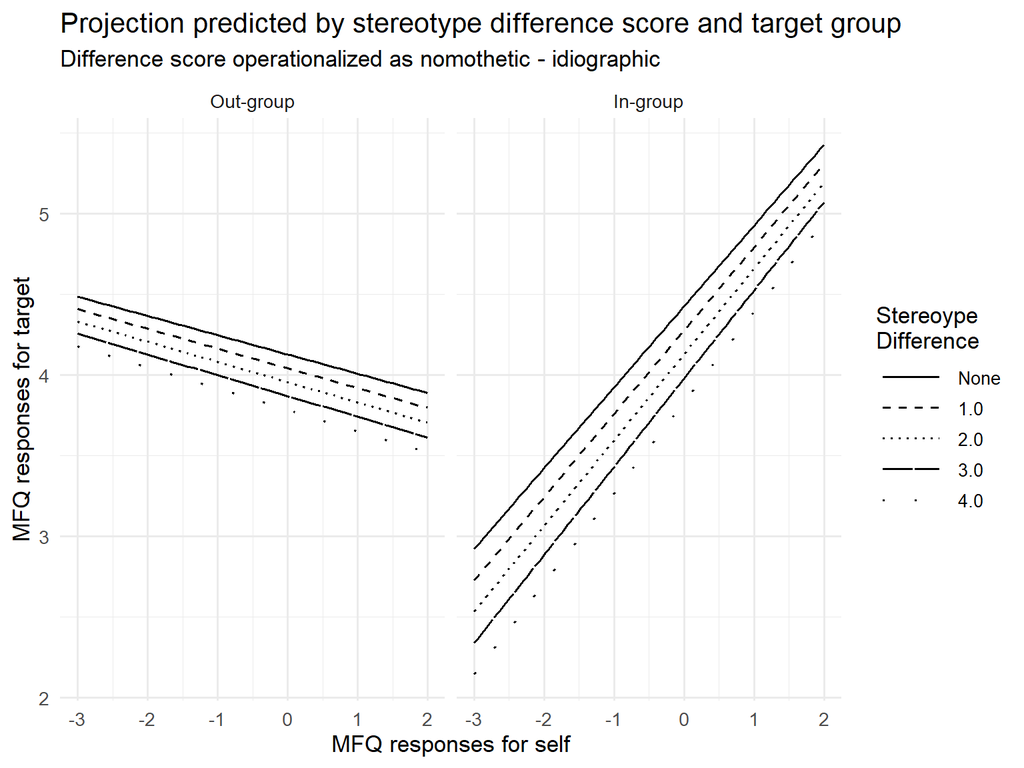

```r
ggplot(nvi_projxdiffxgroup, aes(MFQSelf_c,
                               fit,
                               group = stereo_diff,
                               color = stereo_diff)) +
  geom_smooth(method = "lm", se = FALSE, size = .7, colour = "black",
              aes(linetype = stereo_diff)) +
  facet_wrap(~group, labeller = labeller(group = group_label)) +
  scale_linetype_manual("Stereoype \nDifference", breaks = c(0,1.0,2.0,3.0,4.0),
                       labels = c("None",
                                  "1.0",
                                  "2.0",
                                  "3.0",
                                  "4.0"),
                       values = c("solid",
                                  "dashed",
                                  "dotted",
                                  "F1",
                                  "1F")) +
  theme_minimal(base_size = 13) +
  labs(title = "Projection predicted by stereotype difference score and target group",
       subtitle = "Difference score operationalized as nomothetic - idiographic ",
       x = "MFQ responses for self",
       y = "MFQ responses for target") +
  theme(legend.text = element_text(size = 10),
        legend.key.width = unit(1.4, "cm"))
```

Non-significant interaction, but wanted to show it. Regardless of stereotype difference, people are counter projecting with their out-group target and projecting with their in-group.

```r
nvi_projxdiffxident <- effect(term = "MFQSelf_c:stereo_diff:ident_c",
                             xlevels = list(stereo_diff = c(0,1.0,2.0,3.0,4.0),
                                            ident_c = c(-1.78, 0, 1.78)),
                             mod = nom_v_id_model)

nvi_projxdiffxident <- as.data.frame(nvi_projxdiffxident)

nvi_projxdiffxident$stereo_diff <- as.factor(nvi_projxdiffxident$stereo_diff)
nvi_projxdiffxident$Identification <- as.factor(nvi_projxdiffxident$ident_c)
```

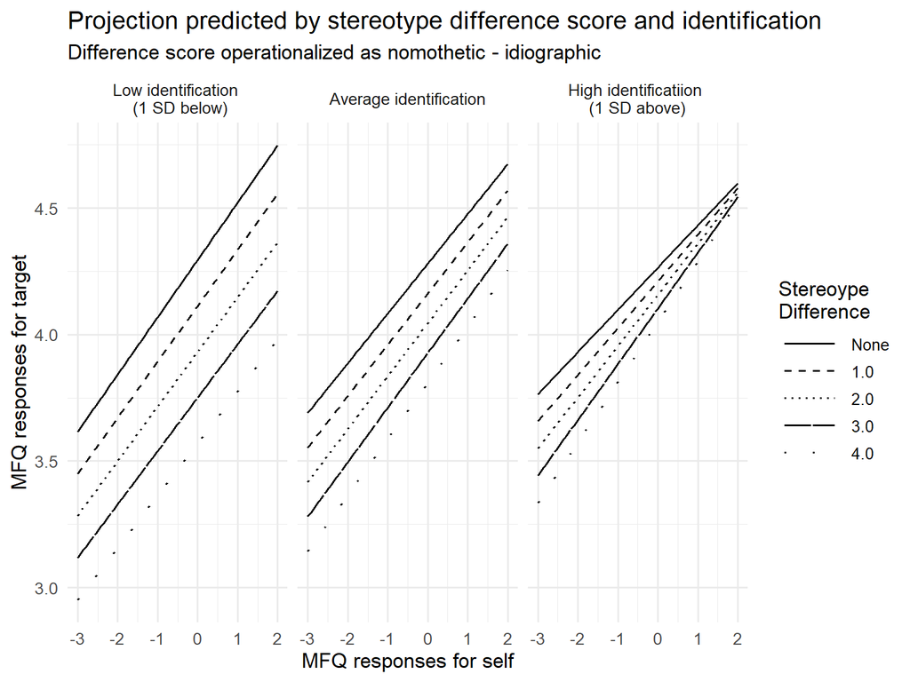

```r
ggplot(nvi_projxdiffxident, aes(MFQSelf_c,
                               fit,
                               group = stereo_diff,
                               color = stereo_diff)) +
  geom_smooth(method = "lm", se = FALSE, size = .7, colour = "black",
              aes(linetype = stereo_diff)) +
  facet_wrap(~Identification, labeller =
               labeller(Identification = ident_label)) +
  scale_linetype_manual("Stereoype \nDifference", breaks = c(0,1.0,2.0,3.0,4.0),
                       labels = c("None",
                                  "1.0",
                                  "2.0",
                                  "3.0",
                                  "4.0"),
                       values = c("solid",
                                  "dashed",
                                  "dotted",
                                  "F1",
                                  "1F")) +
  theme_minimal(base_size = 13) +
  labs(title = "Projection predicted by stereotype difference score and identification",
       subtitle = "Difference score operationalized as nomothetic - idiographic ",
       x = "MFQ responses for self",
       y = "MFQ responses for target") +
  theme(legend.text = element_text(size = 10),
        legend.key.width = unit(1.4, "cm"))
```

As in-group identification increases, people whose individual stereotypes are the same as their group stereotype project less. Interestingly, those who show even a slight difference between stereotypes, continue to project the same amount across in-group identification. Moreover, people whose stereotypes are 2 or more different from the group stereotype’s intercepts increase as identification increases.

```r
nvi_projxdiffxgroupxcand <- effect(term =
                                "MFQSelf_c:stereo_diff:inoutgroup_effects:par_cand",
                             xlevels = list(stereo_diff = c(0,1.0,2.0,3.0,4.0),
                                            inoutgroup_effects = c(-0.5, 0.5),
                                            par_cand = c("Clinton", "Trump")),
                             mod = nom_v_id_model)

nvi_projxdiffxgroupxcand<- as.data.frame(nvi_projxdiffxgroupxcand)

nvi_projxdiffxgroupxcand$stereo_diff <- as.factor(nvi_projxdiffxgroupxcand$stereo_diff)
nvi_projxdiffxgroupxcand$group <- as.factor(nvi_projxdiffxgroupxcand$inoutgroup_effects)
nvi_projxdiffxgroupxcand$cand <- as.factor(nvi_projxdiffxgroupxcand$par_cand)
```

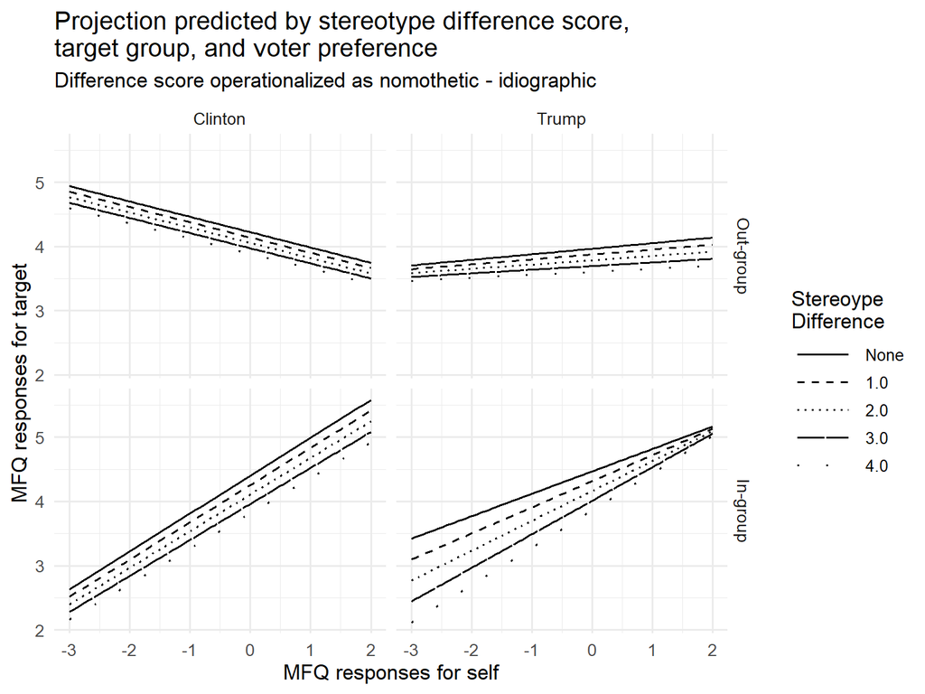

```r
ggplot(nvi_projxdiffxgroupxcand, aes(MFQSelf_c,
                               fit,
                               group = stereo_diff,
                               color = stereo_diff)) +
  geom_smooth(method = "lm", se = FALSE, size = .7, colour = "black",
              aes(linetype = stereo_diff)) +
  facet_grid(group~cand, labeller = labeller(group = group_label)) +
  scale_linetype_manual("Stereoype \nDifference", breaks = c(0,1.0,2.0,3.0,4.0),
                       labels = c("None",
                                  "1.0",
                                  "2.0",
                                  "3.0",
                                  "4.0"),
                       values = c("solid",
                                  "dashed",
                                  "dotted",
                                  "F1",
                                  "1F")) +
  theme_minimal(base_size = 13) +
  labs(title = "Projection predicted by stereotype difference score, \ntarget group, and voter preference",
       subtitle = "Difference score operationalized as nomothetic - idiographic ",
       x = "MFQ responses for self",
       y = "MFQ responses for target") +
  theme(legend.text = element_text(size = 10),
        legend.key.width = unit(1.4, "cm"))
```

Clinton supporters counter project with their out-group regardless of stereotype difference, while Trump supporters either don’t project (at high stereotype difference) to slightly project (as stereotypes become more like the group stereotype). With in-group targets, Clinton supporters project more similarly across stereotype difference, though people whose stereotype’s of their in-group are most similar to the group project the most and those who are the most different project the least. On the other hand, Trump supporters project the least with their in-group when they report the same stereotypes as the group and their projection increases as their stereotype difference increases.

# MFQ sub areas

```r
#separating MFQ into binding and individualizing subscales
mfq_binding <- clean_data2 %>%
  filter(MFQ_Number %in% c("3", "4", "5", "9", "10", "11", "14", "15", "16",
                           "19", "20", "21", "25", "26", "27", "30", "31", "32")) %>%
  select(subid, MFQ_Number, MFQTarg, MFQSelf_c, MFQSelf, MFQStereo_c, MFQStereo, inoutgroup_effects, ident_c, par_cand, Liking, WilltoDiscuss, Valid, Treatment, Contentious) %>%
  unique() %>%
  na.omit()

mfq_individual <- clean_data2 %>%
  filter(MFQ_Number %in% c("1", "2", "7", "8", "12", "13", "17", "18", "23",
                           "24", "28", "29")) %>%
  select(subid, MFQ_Number, MFQTarg, MFQSelf_c, MFQSelf, MFQStereo_c, MFQStereo, inoutgroup_effects, ident_c, par_cand, Liking, WilltoDiscuss, Valid, Treatment, Contentious) %>%
  unique() %>%
  na.omit()
```

## Binding

```r
#model
is_mfqbinding <- lmer(MFQTarg ~ MFQSelf_c * MFQStereo_c *
                                    inoutgroup_effects * ident_c +
                                    (MFQSelf_c|subid),
                                 data = mfq_binding)

#results
tab_model(is_mfqbinding,
          title = "Projection moderated by stereotyping for binding morals")
```

Projection moderated by stereotyping for binding morals

|  | MFQ Targ |  |  |
| --- | --- | --- | --- |
| Predictors | Estimates | CI | p |
| (Intercept) | 4.14 | 4.08 – 4.19 | **<0.001** |
| MFQSelf_c | 0.14 | 0.12 – 0.16 | **<0.001** |
| MFQStereo_c | 0.35 | 0.33 – 0.36 | **<0.001** |
| inoutgroup_effects | -0.08 | -0.19 – 0.02 | 0.134 |
| ident_c | 0.00 | -0.03 – 0.03 | 0.950 |
| MFQSelf_c * MFQStereo_c | -0.01 | -0.02 – -0.00 | **0.014** |
| MFQSelf_c * inoutgroup_effects | 0.30 | 0.26 – 0.34 | **<0.001** |
| MFQStereo_c * inoutgroup_effects | -0.06 | -0.10 – -0.03 | **<0.001** |
| MFQSelf_c * ident_c | 0.00 | -0.01 – 0.02 | 0.456 |
| MFQStereo_c * ident_c | 0.01 | 0.00 – 0.02 | **0.003** |
| inoutgroup_effects * ident_c | 0.21 | 0.15 – 0.27 | **<0.001** |
| (MFQSelf_c * MFQStereo_c) * inoutgroup_effects | -0.04 | -0.06 – -0.02 | **<0.001** |
| (MFQSelf_c * MFQStereo_c) * ident_c | -0.00 | -0.01 – 0.00 | 0.250 |
| (MFQSelf_c *inoutgroup_effects)* ident_c | 0.05 | 0.03 – 0.07 | **<0.001** |
| (MFQStereo_c *inoutgroup_effects)* ident_c | -0.04 | -0.05 – -0.02 | **<0.001** |
| (MFQSelf_c * MFQStereo_c * inoutgroup_effects) * ident_c | -0.02 | -0.03 – -0.01 | **<0.001** |
| Random Effects |  |  |  |
| σ<sup>2</sup> | 0.93 |  |  |
| τ<sub>00</sub> <sub>subid</sub> | 0.44 |  |  |
| τ<sub>11</sub> <sub>subid.MFQSelf_c</sub> | 0.03 |  |  |
| ρ<sub>01</sub> <sub>subid</sub> | 0.01 |  |  |
| ICC | 0.36 |  |  |
| N <sub>subid</sub> | 721 |  |  |
| Observations | 12843 |  |  |
| Marginal R<sup>2</sup> / Conditional R<sup>2</sup> | 0.345 / 0.581 |  |  |

```r
is_binding_3way <- effect(term = "MFQSelf_c:inoutgroup_effects:ident_c",
                           xlevels = list(ident_c = c(-1.78, 0, 1.78),
                                         inoutgroup_effects = c(-.5,.5)),
                           mod = is_mfqbinding)

is_binding_3way <- as.data.frame(is_binding_3way)

is_binding_3way$Group <- as.factor(is_binding_3way$inoutgroup_effects)
is_binding_3way$Identification <- as.factor(is_binding_3way$ident_c)

ident_label <- c("-1.78" = "Low identification \n (1 SD below)",
                 "0" = "Average identification",
                 "1.78" = "High identificatiion \n(1 SD above)")
```

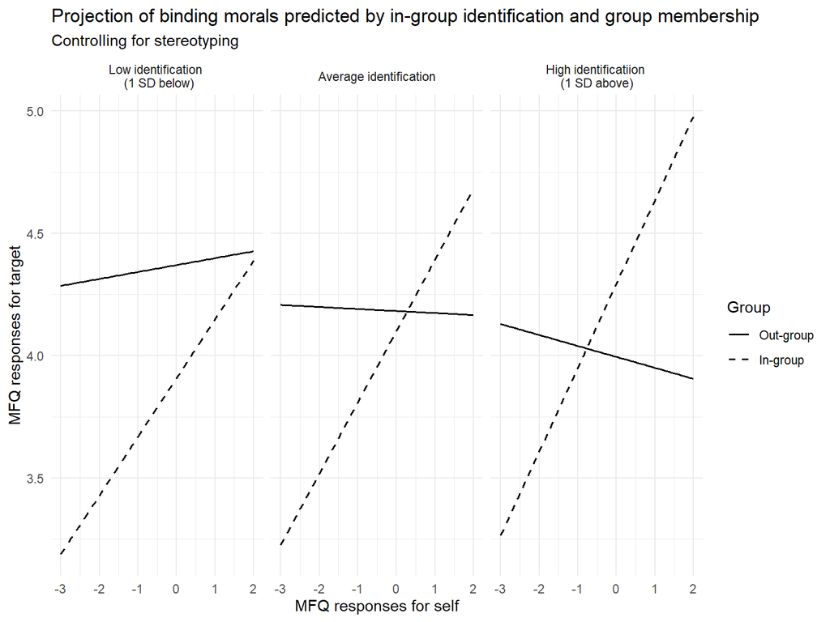

```r
ggplot(is_binding_3way, aes(MFQSelf_c,
                             fit,
                             group = Group,
                             color = Group)) +
  geom_smooth(method = "lm", se = FALSE, size = .7, colour = "black",
              aes(linetype = Group)) +
  facet_wrap(~Identification, labeller =
               labeller(Identification = ident_label)) +
  scale_linetype_manual("Group", breaks = c(-.5, .5),
                       labels = c("Out-group", "In-group"),
                       values = c("solid",
                                   "dashed")) +
  theme_minimal() +
  labs(title = "Projection of binding morals predicted by in-group identification and group membership",
       subtitle = "Controlling for stereotyping",
       x = "MFQ responses for self",
       y = "MFQ responses for target")
```

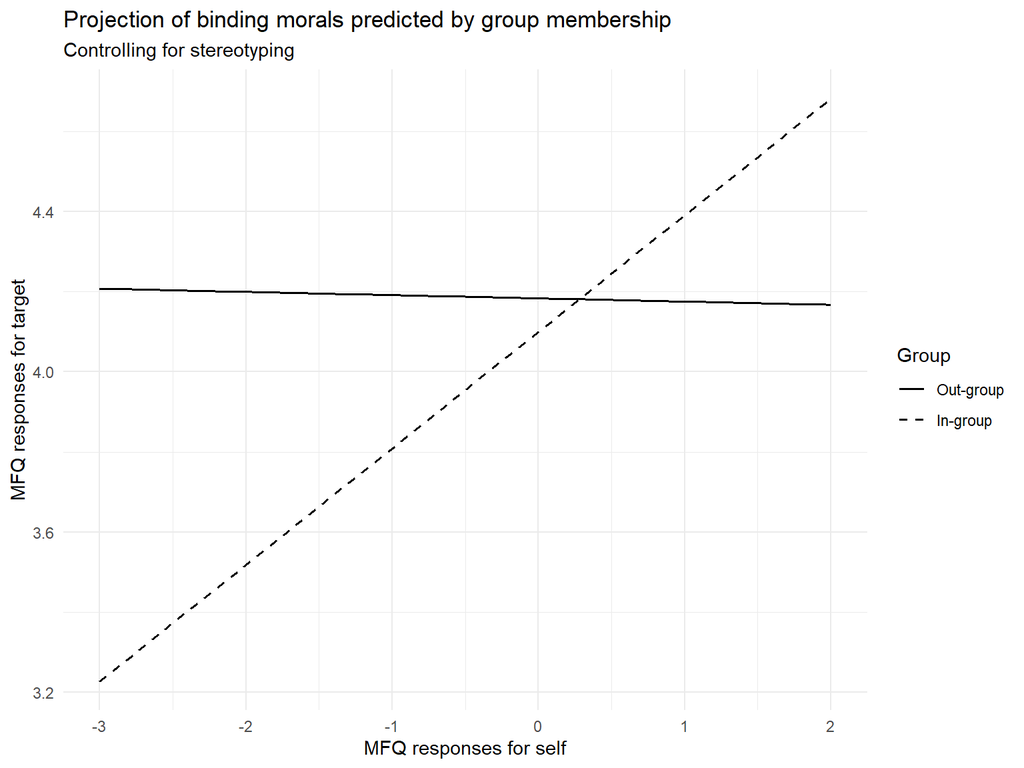

```r
ggplot(is_binding_group, aes(MFQSelf_c,
                               fit,
                               group = Group,
                               color = Group)) +
  geom_smooth(method = "lm", se = FALSE, size = .7, colour = "black",
              aes(linetype = Group)) +
  scale_linetype_manual("Group", breaks = c(-.5, .5),
                       labels = c("Out-group", "In-group"),
                       values = c("solid",
                                  "dashed")) +
  theme_minimal() +
  labs(title = "Projection of binding morals predicted by group membership",
       subtitle = "Controlling for stereotyping",
       x = "MFQ responses for self",
       y = "MFQ responses for target")
```

## Binding including participant vote

```r
is_mfqbinding_cand <- lmer(MFQTarg ~ MFQSelf_c * MFQStereo_c *
                                    inoutgroup_effects * ident_c * par_cand +
                                    (MFQSelf_c|subid),
                                 data = mfq_binding)

tab_model(is_mfqbinding_cand,
          title = "Projection moderated by stereotyping for binding morals")
```

Projection moderated by stereotyping for binding morals

|  | MFQ Targ |  |  |
| --- | --- | --- | --- |
| Predictors | Estimates | CI | p |
| (Intercept) | 4.32 | 4.25 – 4.39 | **<0.001** |
| MFQSelf_c | 0.14 | 0.11 – 0.17 | **<0.001** |
| MFQStereo_c | 0.34 | 0.31 – 0.36 | **<0.001** |
| inoutgroup_effects | -0.51 | -0.65 – -0.37 | **<0.001** |
| ident_c | 0.09 | 0.05 – 0.14 | **<0.001** |
| par_cand Trump | -0.36 | -0.48 – -0.24 | **<0.001** |
| MFQSelf_c * MFQStereo_c | -0.00 | -0.01 – 0.01 | 0.671 |
| MFQSelf_c * inoutgroup_effects | 0.32 | 0.26 – 0.37 | **<0.001** |
| MFQStereo_c * inoutgroup_effects | 0.04 | -0.00 – 0.08 | 0.060 |
| MFQSelf_c * ident_c | 0.01 | -0.01 – 0.03 | 0.247 |
| MFQStereo_c * ident_c | 0.00 | -0.01 – 0.01 | 0.982 |
| inoutgroup_effects * ident_c | 0.04 | -0.05 – 0.14 | 0.345 |
| MFQSelf_c * par_cand Trump | 0.01 | -0.04 – 0.06 | 0.661 |
| MFQStereo_c * par_cand Trump | -0.01 | -0.05 – 0.02 | 0.536 |
| inoutgroup_effects * par_cand Trump | 1.11 | 0.87 – 1.36 | **<0.001** |
| ident_c * par_cand Trump | -0.06 | -0.13 – 0.00 | 0.055 |
| (MFQSelf_c * MFQStereo_c) * inoutgroup_effects | -0.04 | -0.07 – -0.02 | **<0.001** |
| (MFQSelf_c * MFQStereo_c) * ident_c | -0.00 | -0.01 – 0.00 | 0.433 |
| (MFQSelf_c *inoutgroup_effects)* ident_c | 0.06 | 0.02 – 0.10 | **0.001** |
| (MFQStereo_c *inoutgroup_effects)* ident_c | 0.02 | -0.01 – 0.04 | 0.267 |
| (MFQSelf_c * MFQStereo_c) * par_cand Trump | -0.03 | -0.05 – -0.01 | **0.009** |
| (MFQSelf_c *inoutgroup_effects)* par_cand Trump | 0.02 | -0.08 – 0.12 | 0.667 |
| (MFQStereo_c *inoutgroup_effects)* par_cand Trump | -0.19 | -0.27 – -0.12 | **<0.001** |
| (MFQSelf_c * ident_c) * par_cand Trump | -0.01 | -0.04 – 0.01 | 0.259 |
| (MFQStereo_c * ident_c) * par_cand Trump | 0.02 | 0.00 – 0.04 | **0.020** |
| (inoutgroup_effects *ident_c)* par_cand Trump | -0.00 | -0.13 – 0.13 | 0.982 |
| (MFQSelf_c * MFQStereo_c * inoutgroup_effects) * ident_c | -0.02 | -0.03 – -0.00 | **0.014** |
| (MFQSelf_c * MFQStereo_c * inoutgroup_effects) * par_cand Trump | 0.01 | -0.03 – 0.05 | 0.640 |
| (MFQSelf_c * MFQStereo_c * ident_c) * par_cand Trump | 0.01 | -0.00 – 0.02 | 0.175 |
| (MFQSelf_c *inoutgroup_effects* ident_c) * par_cand Trump | -0.03 | -0.08 – 0.02 | 0.217 |
| (MFQStereo_c *inoutgroup_effects* ident_c) * par_cand Trump | -0.05 | -0.09 – -0.01 | **0.008** |
| (MFQSelf_c * MFQStereo_c * inoutgroup_effects *ident_c)* par_cand Trump | 0.01 | -0.01 – 0.03 | 0.439 |
| Random Effects |  |  |  |
| σ<sup>2</sup> | 0.93 |  |  |
| τ<sub>00</sub> <sub>subid</sub> | 0.37 |  |  |
| τ<sub>11</sub> <sub>subid.MFQSelf_c</sub> | 0.03 |  |  |
| ρ<sub>01</sub> <sub>subid</sub> | 0.02 |  |  |
| ICC | 0.33 |  |  |
| N <sub>subid</sub> | 721 |  |  |
| Observations | 12843 |  |  |
| Marginal R<sup>2</sup> / Conditional R<sup>2</sup> | 0.406 / 0.604 |  |  |

```r
bind_group_cand <- effect(term = "MFQSelf_c:inoutgroup_effects:par_cand",
                             xlevels = list(inoutgroup_effects = c(-.5,.5),
                                            par_cand = c("Clinton", "Trump")),
                             mod = is_mfqbinding_cand)

bind_group_cand <- as.data.frame(bind_group_cand)

bind_group_cand$Group <- as.factor(bind_group_cand$inoutgroup_effects)
```

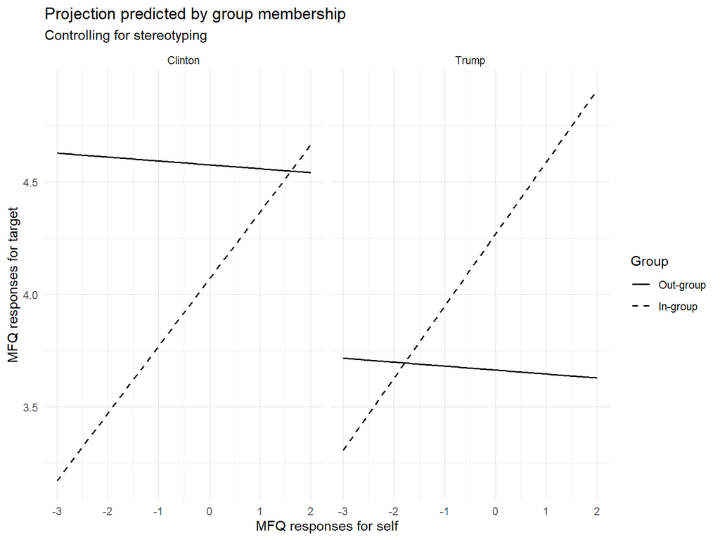

```r
ggplot(bind_group_cand, aes(MFQSelf_c,
                               fit,
                               group = Group,
                               color = Group)) +
  geom_smooth(method = "lm", se = FALSE, size = .7, colour = "black",
              aes(linetype = Group)) +
  facet_wrap(~par_cand)+
  scale_linetype_manual("Group", breaks = c(-.5, .5),
                       labels = c("Out-group", "In-group"),
                       values = c("solid",
                                  "dashed")) +
  theme_minimal() +
  labs(title = "Projection predicted by group membership",
       subtitle = "Controlling for stereotyping",
       x = "MFQ responses for self",
       y = "MFQ responses for target")
```

## Individualizing

```r
is_mfqindividual <- lmer(MFQTarg ~ MFQSelf_c * MFQStereo_c *
                                    inoutgroup_effects * ident_c +
                                    (MFQSelf_c|subid),
                                 data = mfq_individual)

tab_model(is_mfqindividual,
          title = "Projection moderated by stereotyping for individualizing morals")
```

Projection moderated by stereotyping for individualizing morals

|  | MFQ Targ |  |  |
| --- | --- | --- | --- |
| Predictors | Estimates | CI | p |
| (Intercept) | 4.26 | 4.20 – 4.31 | **<0.001** |
| MFQSelf_c | 0.19 | 0.17 – 0.22 | **<0.001** |
| MFQStereo_c | 0.36 | 0.35 – 0.38 | **<0.001** |
| inoutgroup_effects | 0.45 | 0.34 – 0.56 | **<0.001** |
| ident_c | 0.04 | 0.01 – 0.07 | **0.018** |
| MFQSelf_c * MFQStereo_c | -0.03 | -0.04 – -0.02 | **<0.001** |
| MFQSelf_c * inoutgroup_effects | 0.29 | 0.25 – 0.34 | **<0.001** |
| MFQStereo_c * inoutgroup_effects | -0.09 | -0.13 – -0.05 | **<0.001** |
| MFQSelf_c * ident_c | -0.00 | -0.02 – 0.01 | 0.608 |
| MFQStereo_c * ident_c | 0.00 | -0.01 – 0.01 | 0.952 |
| inoutgroup_effects * ident_c | -0.11 | -0.17 – -0.05 | **0.001** |
| (MFQSelf_c * MFQStereo_c) * inoutgroup_effects | -0.04 | -0.06 – -0.02 | **<0.001** |
| (MFQSelf_c * MFQStereo_c) * ident_c | 0.00 | -0.00 – 0.01 | 0.261 |
| (MFQSelf_c *inoutgroup_effects)* ident_c | 0.03 | 0.00 – 0.05 | **0.025** |
| (MFQStereo_c *inoutgroup_effects)* ident_c | 0.01 | -0.01 – 0.03 | 0.220 |
| (MFQSelf_c * MFQStereo_c * inoutgroup_effects) * ident_c | -0.00 | -0.01 – 0.01 | 0.767 |
| Random Effects |  |  |  |
| σ<sup>2</sup> | 0.82 |  |  |
| τ<sub>00</sub> <sub>subid</sub> | 0.43 |  |  |
| τ<sub>11</sub> <sub>subid.MFQSelf_c</sub> | 0.04 |  |  |
| ρ<sub>01</sub> <sub>subid</sub> | 0.10 |  |  |
| ICC | 0.40 |  |  |
| N <sub>subid</sub> | 721 |  |  |
| Observations | 8549 |  |  |
| Marginal R<sup>2</sup> / Conditional R<sup>2</sup> | 0.390 / 0.632 |  |  |

```r
describe(mfq_individual$ident_c)
```

```
##    vars    n  mean  sd median trimmed mad   min  max range  skew kurtosis   se
## X1    1 8549 -0.01 1.8   0.06       0 1.8 -4.23 3.77     8 -0.04    -0.37 0.02
```

```r
is_indiv_3way <- effect(term = "MFQSelf_c:inoutgroup_effects:ident_c",
                           xlevels = list(ident_c = c(-1.78, 0, 1.78),
                                         inoutgroup_effects = c(-.5,.5)),
                           mod = is_mfqindividual)

is_indiv_3way <- as.data.frame(is_indiv_3way)

is_indiv_3way$Group <- as.factor(is_indiv_3way$inoutgroup_effects)
is_indiv_3way$Identification <- as.factor(is_indiv_3way$ident_c)

ident_label <- c("-1.78" = "Low identification \n (1 SD below)",
                 "0" = "Average identification",
                 "1.78" = "High identificatiion \n(1 SD above)")
```

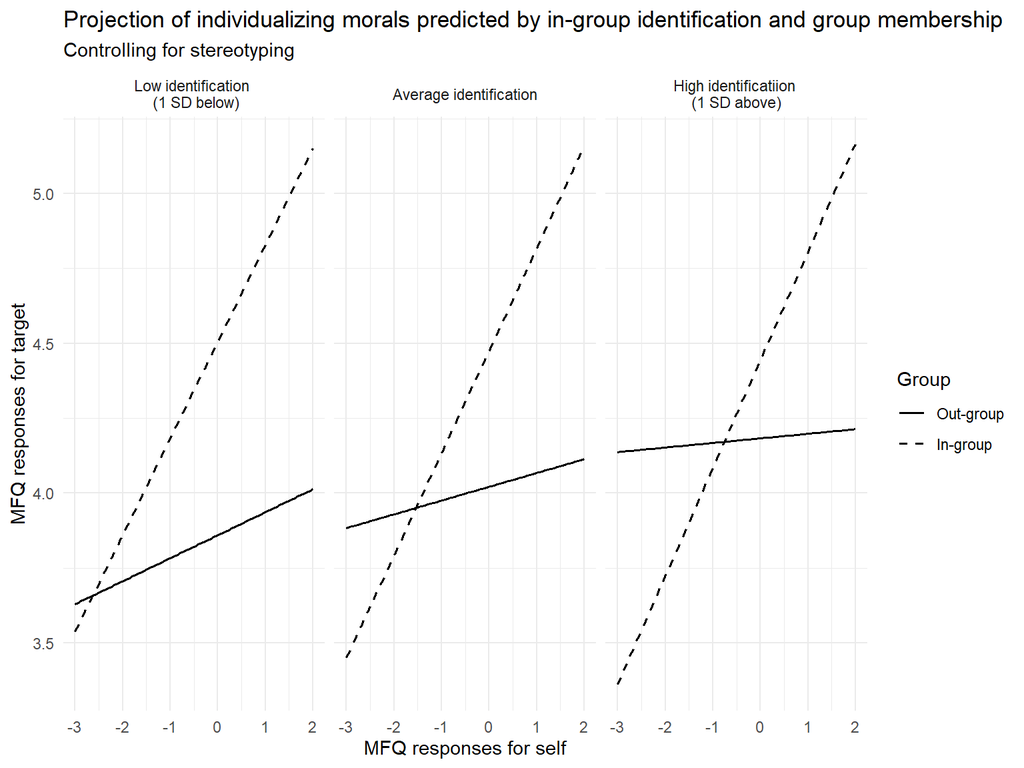

```r
ggplot(is_indiv_3way, aes(MFQSelf_c,
                             fit,
                             group = Group,
                             color = Group)) +
  geom_smooth(method = "lm", se = FALSE, size = .7, colour = "black",
              aes(linetype = Group)) +
  facet_wrap(~Identification, labeller =
               labeller(Identification = ident_label)) +
  scale_linetype_manual("Group", breaks = c(-.5, .5),
                       labels = c("Out-group", "In-group"),
                       values = c("solid",
                                   "dashed")) +
  theme_minimal() +
  labs(title = "Projection of individualizing morals predicted by in-group identification and group membership",
       subtitle = "Controlling for stereotyping",
       x = "MFQ responses for self",
       y = "MFQ responses for target")
```

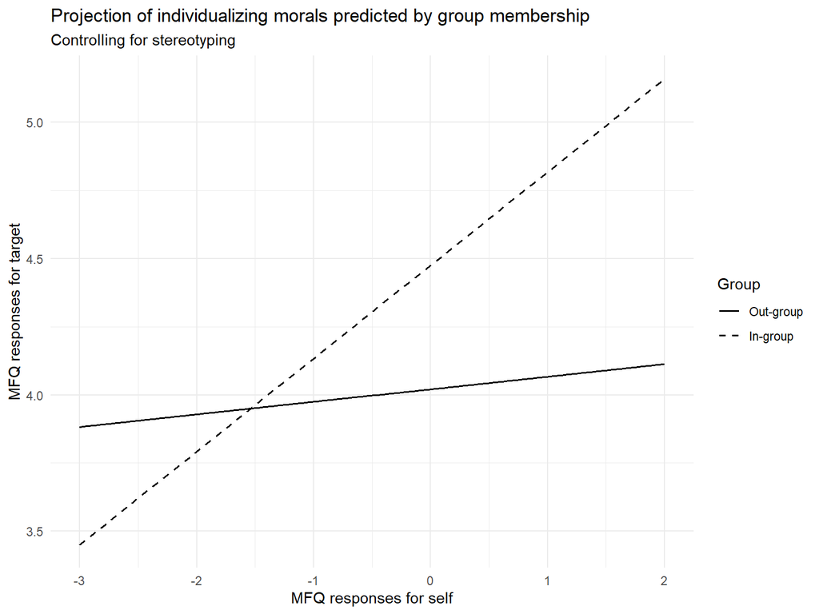

```r
ggplot(is_indiv_group, aes(MFQSelf_c,
                               fit,
                               group = Group,
                               color = Group)) +
  geom_smooth(method = "lm", se = FALSE, size = .7, colour = "black",
              aes(linetype = Group)) +
  scale_linetype_manual("Group", breaks = c(-.5, .5),
                       labels = c("Out-group", "In-group"),
                       values = c("solid",
                                  "dashed")) +
  theme_minimal() +
  labs(title = "Projection of individualizing morals predicted by group membership",
       subtitle = "Controlling for stereotyping",
       x = "MFQ responses for self",
       y = "MFQ responses for target")
```

## Individualizing including participant vote

```r
#model
is_mfqindividual_cand <- lmer(MFQTarg ~ MFQSelf_c * MFQStereo_c *
                                    inoutgroup_effects * ident_c * par_cand +
                                    (MFQSelf_c|subid),
                                 data = mfq_individual)

#results
tab_model(is_mfqindividual_cand,
          title = "Projection moderated by stereotyping for individual morals")
```

Projection moderated by stereotyping for individual morals

|  | MFQ Targ |  |  |
| --- | --- | --- | --- |
| Predictors | Estimates | CI | p |
| (Intercept) | 4.18 | 4.10 – 4.26 | **<0.001** |
| MFQSelf_c | 0.19 | 0.16 – 0.23 | **<0.001** |
| MFQStereo_c | 0.37 | 0.34 – 0.40 | **<0.001** |
| inoutgroup_effects | 0.90 | 0.74 – 1.06 | **<0.001** |
| ident_c | -0.01 | -0.06 – 0.04 | 0.815 |
| par_cand Trump | 0.19 | 0.07 – 0.32 | **0.003** |
| MFQSelf_c * MFQStereo_c | -0.05 | -0.06 – -0.03 | **<0.001** |
| MFQSelf_c * inoutgroup_effects | 0.35 | 0.27 – 0.42 | **<0.001** |
| MFQStereo_c * inoutgroup_effects | -0.17 | -0.23 – -0.11 | **<0.001** |
| MFQSelf_c * ident_c | -0.01 | -0.03 – 0.02 | 0.627 |
| MFQStereo_c * ident_c | 0.01 | -0.01 – 0.03 | 0.165 |
| inoutgroup_effects * ident_c | 0.05 | -0.05 – 0.15 | 0.300 |
| MFQSelf_c * par_cand Trump | -0.00 | -0.06 – 0.06 | 0.961 |
| MFQStereo_c * par_cand Trump | -0.02 | -0.06 – 0.03 | 0.487 |
| inoutgroup_effects * par_cand Trump | -1.23 | -1.48 – -0.98 | **<0.001** |
| ident_c * par_cand Trump | 0.03 | -0.04 – 0.10 | 0.341 |
| (MFQSelf_c * MFQStereo_c) * inoutgroup_effects | -0.00 | -0.04 – 0.03 | 0.843 |
| (MFQSelf_c * MFQStereo_c) * ident_c | -0.00 | -0.01 – 0.01 | 0.452 |
| (MFQSelf_c *inoutgroup_effects)* ident_c | 0.05 | 0.01 – 0.10 | **0.027** |
| (MFQStereo_c *inoutgroup_effects)* ident_c | -0.02 | -0.06 – 0.01 | 0.233 |
| (MFQSelf_c * MFQStereo_c) * par_cand Trump | 0.02 | -0.01 – 0.04 | 0.192 |
| (MFQSelf_c *inoutgroup_effects)* par_cand Trump | -0.12 | -0.24 – -0.01 | **0.035** |
| (MFQStereo_c *inoutgroup_effects)* par_cand Trump | 0.17 | 0.08 – 0.26 | **<0.001** |
| (MFQSelf_c * ident_c) * par_cand Trump | -0.00 | -0.03 – 0.03 | 0.858 |
| (MFQStereo_c * ident_c) * par_cand Trump | -0.01 | -0.04 – 0.01 | 0.255 |
| (inoutgroup_effects *ident_c)* par_cand Trump | -0.01 | -0.14 – 0.13 | 0.924 |
| (MFQSelf_c * MFQStereo_c * inoutgroup_effects) * ident_c | 0.02 | 0.00 – 0.04 | **0.039** |
| (MFQSelf_c * MFQStereo_c * inoutgroup_effects) * par_cand Trump | -0.04 | -0.09 – 0.01 | 0.153 |
| (MFQSelf_c * MFQStereo_c * ident_c) * par_cand Trump | 0.01 | -0.01 – 0.02 | 0.279 |
| (MFQSelf_c *inoutgroup_effects* ident_c) * par_cand Trump | -0.01 | -0.07 – 0.05 | 0.698 |
| (MFQStereo_c *inoutgroup_effects* ident_c) * par_cand Trump | 0.02 | -0.02 – 0.07 | 0.353 |
| (MFQSelf_c * MFQStereo_c * inoutgroup_effects *ident_c)* par_cand Trump | -0.03 | -0.05 – -0.00 | **0.033** |
| Random Effects |  |  |  |
| σ<sup>2</sup> | 0.81 |  |  |
| τ<sub>00</sub> <sub>subid</sub> | 0.36 |  |  |
| τ<sub>11</sub> <sub>subid.MFQSelf_c</sub> | 0.04 |  |  |
| ρ<sub>01</sub> <sub>subid</sub> | 0.09 |  |  |
| ICC | 0.36 |  |  |
| N <sub>subid</sub> | 721 |  |  |
| Observations | 8549 |  |  |
| Marginal R<sup>2</sup> / Conditional R<sup>2</sup> | 0.449 / 0.648 |  |  |

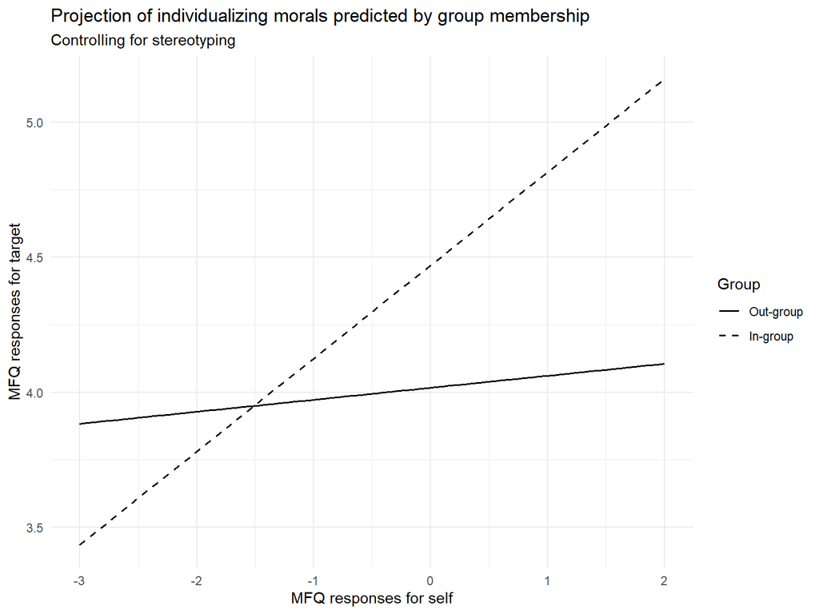

```r
ggplot(is_indiv_group_cand, aes(MFQSelf_c,
                               fit,
                               group = Group,
                               color = Group)) +
  geom_smooth(method = "lm", se = FALSE, size = .7, colour = "black",
              aes(linetype = Group)) +
  scale_linetype_manual("Group", breaks = c(-.5, .5),
                       labels = c("Out-group", "In-group"),
                       values = c("solid",
                                  "dashed")) +
  theme_minimal() +
  labs(title = "Projection of individualizing morals predicted by group membership",
       subtitle = "Controlling for stereotyping",
       x = "MFQ responses for self",
       y = "MFQ responses for target")
```

# Demographic differences in counter projection

## Race

```r
dem_analysis <- clean_data2 %>%
  select(subid, MFQ_Number, MFQSelf_c, MFQStereo_c, MFQTarg, ident_c, PT_effects,
         inoutgroup_effects, par_cand, Race) %>%
  unique() %>%
  na.omit()

projmodel_stereo_race <- lmer(MFQTarg ~ MFQSelf_c * MFQStereo_c *
                                    inoutgroup_effects * ident_c * Race +
                                    (MFQSelf_c|subid),
                                 data = dem_analysis)

tab_model(projmodel_stereo_race,
          title = "Projection moderated by stereotyping and race")
```

Projection moderated by stereotyping and race

|  | MFQ Targ |  |  |
| --- | --- | --- | --- |
| Predictors | Estimates | CI | p |
| (Intercept) | 4.35 | 3.62 – 5.08 | **<0.001** |
| MFQSelf_c | 0.53 | 0.16 – 0.90 | **0.005** |
| MFQStereo_c | 0.53 | 0.29 – 0.77 | **<0.001** |
| inoutgroup_effects | -0.59 | -2.01 – 0.82 | 0.414 |
| ident_c | -0.00 | -0.41 – 0.41 | 0.992 |
| Race [Asian] | -0.20 | -0.95 – 0.55 | 0.599 |
| Race [Black] | -0.20 | -0.95 – 0.54 | 0.590 |
| Race [Latinx] | -0.06 | -0.81 – 0.69 | 0.871 |
| Race [Middle Eastern] | -0.41 | -1.86 – 1.05 | 0.582 |
| Race [Caucasian] | -0.17 | -0.90 – 0.57 | 0.655 |
| Race [Multiracial] | -0.06 | -0.82 – 0.70 | 0.882 |
| Race [Other] | 0.34 | -0.67 – 1.36 | 0.509 |
| MFQSelf_c * MFQStereo_c | 0.01 | -0.10 – 0.11 | 0.920 |
| MFQSelf_c * inoutgroup_effects | 0.36 | -0.36 – 1.07 | 0.328 |
| MFQStereo_c * inoutgroup_effects | -0.87 | -1.36 – -0.39 | **<0.001** |
| MFQSelf_c * ident_c | -0.13 | -0.35 – 0.10 | 0.279 |
| MFQStereo_c * ident_c | 0.10 | -0.12 – 0.32 | 0.375 |
| inoutgroup_effects * ident_c | 0.23 | -0.00 – 0.47 | 0.053 |
| MFQSelf_c * Race [Asian] | -0.41 | -0.79 – -0.03 | **0.034** |
| MFQSelf_c * Race [Black] | -0.37 | -0.75 – 0.00 | 0.051 |
| MFQSelf_c * Race [Latinx] | -0.35 | -0.73 – 0.03 | 0.072 |
| MFQSelf_c * Race [Middle Eastern] | -1.04 | -2.46 – 0.37 | 0.148 |
| MFQSelf_c * Race [Caucasian] | -0.36 | -0.73 – 0.00 | 0.053 |
| MFQSelf_c * Race [Multiracial] | -0.42 | -0.80 – -0.03 | **0.035** |
| MFQSelf_c * Race [Other] | -0.16 | -0.72 – 0.39 | 0.562 |
| MFQStereo_c * Race [Asian] | -0.11 | -0.35 – 0.14 | 0.396 |
| MFQStereo_c * Race [Black] | -0.21 | -0.45 – 0.04 | 0.094 |
| MFQStereo_c * Race [Latinx] | -0.16 | -0.40 – 0.09 | 0.215 |
| MFQStereo_c * Race [Middle Eastern] | 0.06 | -0.70 – 0.81 | 0.881 |

[output cut: 84 more lines]

Model is rank deficient, not enough power to check if results differ by race. Could possibly do white vs minorities, but that doesn’t feel telling enough.

## Gender

```r
gender_analysis <- clean_data2 %>%
  select(subid, MFQ_Number, MFQSelf_c, MFQStereo_c, MFQTarg, ident_c, PT_effects,
         inoutgroup_effects, par_cand, Gender) %>%
  unique() %>%
  na.omit()

projmodel_stereo_gender <- lmer(MFQTarg ~ MFQSelf_c * MFQStereo_c *
                                    inoutgroup_effects * ident_c * Gender +
                                    (MFQSelf_c|subid),
                                 data = gender_analysis)

tab_model(projmodel_stereo_gender,
          title = "Projection moderated by stereotyping and gender")
```

Projection moderated by stereotyping and gender

|  | MFQ Targ |  |  |
| --- | --- | --- | --- |
| Predictors | Estimates | CI | p |
| (Intercept) | 4.10 | 4.04 – 4.16 | **<0.001** |
| MFQSelf_c | 0.15 | 0.12 – 0.19 | **<0.001** |
| MFQStereo_c | 0.45 | 0.43 – 0.47 | **<0.001** |
| inoutgroup_effects | 0.20 | 0.07 – 0.32 | **0.002** |
| ident_c | 0.04 | 0.00 – 0.07 | **0.025** |
| Gender [Female] | 0.12 | 0.04 – 0.20 | **0.002** |
| Gender [Other] | -0.01 | -0.75 – 0.72 | 0.971 |
| MFQSelf_c * MFQStereo_c | -0.00 | -0.01 – 0.01 | 0.860 |
| MFQSelf_c * inoutgroup_effects | 0.36 | 0.29 – 0.43 | **<0.001** |
| MFQStereo_c * inoutgroup_effects | -0.19 | -0.23 – -0.15 | **<0.001** |
| MFQSelf_c * ident_c | 0.00 | -0.02 – 0.02 | 0.970 |
| MFQStereo_c * ident_c | 0.01 | -0.00 – 0.02 | 0.162 |
| inoutgroup_effects * ident_c | 0.05 | -0.02 – 0.12 | 0.192 |
| MFQSelf_c * Gender [Female] | 0.00 | -0.04 – 0.05 | 0.839 |
| MFQSelf_c * Gender [Other] | 0.12 | -0.25 – 0.49 | 0.527 |
| MFQStereo_c * Gender [Female] | 0.01 | -0.01 – 0.04 | 0.265 |
| MFQStereo_c * Gender [Other] | -0.16 | -0.48 – 0.17 | 0.340 |
| inoutgroup_effects * Gender [Female] | -0.11 | -0.26 – 0.04 | 0.163 |
| inoutgroup_effects * Gender [Other] | 0.15 | -1.32 – 1.61 | 0.846 |
| ident_c * Gender [Female] | -0.02 | -0.06 – 0.02 | 0.355 |
| ident_c * Gender [Other] | -0.25 | -0.52 – 0.03 | 0.084 |
| (MFQSelf_c * MFQStereo_c) * inoutgroup_effects | -0.01 | -0.04 – 0.01 | 0.215 |
| (MFQSelf_c * MFQStereo_c) * ident_c | 0.00 | -0.00 – 0.01 | 0.660 |
| (MFQSelf_c *inoutgroup_effects)* ident_c | 0.04 | 0.01 – 0.08 | **0.026** |
| (MFQStereo_c *inoutgroup_effects)* ident_c | -0.08 | -0.11 – -0.06 | **<0.001** |
| (MFQSelf_c * MFQStereo_c) * Gender [Female] | -0.01 | -0.02 – 0.01 | 0.308 |
| (MFQSelf_c * MFQStereo_c) * Gender [Other] | -0.12 | -0.27 – 0.03 | 0.113 |
| (MFQSelf_c *inoutgroup_effects)* Gender [Female] | 0.02 | -0.06 – 0.10 | 0.670 |
| (MFQSelf_c *inoutgroup_effects)* Gender [Other] | -0.47 | -1.22 – 0.27 | 0.212 |
| (MFQStereo_c *inoutgroup_effects)* Gender [Female] | 0.06 | 0.01 – 0.11 | **0.012** |
| (MFQStereo_c *inoutgroup_effects)* Gender [Other] | 0.23 | -0.42 – 0.88 | 0.485 |
| (MFQSelf_c * ident_c) * Gender [Female] | 0.00 | -0.02 – 0.02 | 0.890 |
| (MFQSelf_c * ident_c) * Gender [Other] | -0.02 | -0.16 – 0.12 | 0.750 |
| (MFQStereo_c * ident_c) * Gender [Female] | -0.01 | -0.03 – 0.00 | 0.053 |
| (MFQStereo_c * ident_c) * Gender [Other] | 0.04 | -0.15 – 0.23 | 0.674 |
| (inoutgroup_effects *ident_c)* Gender [Female] | -0.00 | -0.09 – 0.08 | 0.920 |
| (inoutgroup_effects *ident_c)* Gender [Other] | 0.12 | -0.44 – 0.68 | 0.673 |
| (MFQSelf_c * MFQStereo_c * inoutgroup_effects) * ident_c | -0.03 | -0.04 – -0.02 | **<0.001** |
| (MFQSelf_c * MFQStereo_c * inoutgroup_effects) * Gender [Female] | -0.02 | -0.04 – 0.01 | 0.249 |
| (MFQSelf_c * MFQStereo_c * inoutgroup_effects) * Gender [Other] | -0.05 | -0.35 – 0.25 | 0.747 |
| (MFQSelf_c * MFQStereo_c * ident_c) * Gender [Female] | -0.01 | -0.01 – 0.00 | 0.096 |
| (MFQSelf_c * MFQStereo_c * ident_c) * Gender [Other] | -0.03 | -0.10 – 0.04 | 0.416 |
| (MFQSelf_c *inoutgroup_effects* ident_c) * Gender [Female] | -0.02 | -0.06 – 0.03 | 0.511 |
| (MFQSelf_c *inoutgroup_effects* ident_c) * Gender [Other] | -0.22 | -0.50 – 0.06 | 0.124 |
| (MFQStereo_c *inoutgroup_effects* ident_c) * Gender [Female] | 0.06 | 0.04 – 0.09 | **<0.001** |
| (MFQStereo_c *inoutgroup_effects* ident_c) * Gender [Other] | 0.27 | -0.11 – 0.64 | 0.161 |
| (MFQSelf_c * MFQStereo_c * inoutgroup_effects *ident_c)* Gender [Female] | 0.02 | 0.00 – 0.03 | **0.032** |
| (MFQSelf_c * MFQStereo_c * inoutgroup_effects *ident_c)* Gender [Other] | 0.05 | -0.10 – 0.19 | 0.533 |
| Random Effects |  |  |  |
| σ<sup>2</sup> | 1.06 |  |  |
| τ<sub>00</sub> <sub>subid</sub> | 0.19 |  |  |
| τ<sub>11</sub> <sub>subid.MFQSelf_c</sub> | 0.05 |  |  |
| ρ<sub>01</sub> <sub>subid</sub> | 0.05 |  |  |
| ICC | 0.23 |  |  |
| N <sub>subid</sub> | 725 |  |  |
| Observations | 21509 |  |  |
| Marginal R<sup>2</sup> / Conditional R<sup>2</sup> | 0.429 / 0.560 |  |  |